# ESD113-Probabilités et statistique avec R

- Montrer tout le code
- Cacher tout le code
- Voir les sources

De l’introduction à R au clustering : Keno, Tidyverse et méthodes non supervisées

Auteur·rice

Auditeur CNAM : Alban VIDELOUP

Date de publication

10 juin 2026

Résumé

Ce rapport présente une synthèse exhaustive des travaux menés dans le cadre de l’unité d’enseignement ESD113 - Probabilités et statistique avec R, dispensée au Conservatoire National des Arts et Métiers Paris (CNAM). L’objectif central de ce document est de décrire une chaîne de traitement de données complète, allant de l’acquisition et de la restructuration des données brutes jusqu’à la modélisation statistique et la production de rapports de haute qualité typographique via Quarto et LaTeX. La première partie du rapport pose les bases de l’écosystème R en s’appuyant sur la philosophie du Tidyverse, illustrant comment des packages tels que dplyr, ggplot2 et tidyr transforment la manipulation des données en une grammaire fluide et reproductible, permettant de passer d’un format large à un format long indispensable à l’analyse moderne. Le cœur du rapport se concentre sur l’analyse approfondie du jeu de tirage Keno de la Française des Jeux, un cas d’étude réel permettant d’éprouver les concepts de variables aléatoires et de lois de probabilité. En utilisant la loi hypergéométrique, nous démontrons mathématiquement que l’espérance de gain est systématiquement défavorable au joueur, avec un Taux de Retour Joueur (TRJ) oscillant entre 47% et 55% selon le type de grille choisie, mettant ainsi en lumière la marge structurelle de l’opérateur. Cette approche théorique est complétée par des simulations de Monte-Carlo (plus de 1 000 itérations), validant par l’empirisme les résultats probabilistes et explorant la variabilité des minima d’apparition des numéros sur des séries de tirages historiques réels, ce qui permet de rejeter toute hypothèse de biais dans le hasard du tirage. La dernière phase du document explore les méthodes d’apprentissage non supervisé à travers une étude comparative de trois paradigmes majeurs : le partitionnement géométrique par K-means, la classification hiérarchique ascendante (CHA) et les modèles de mélanges gaussiens (GMM) via le package R Mclust. En s’appuyant sur des données simulées contrôlées reproduisant les travaux de Flynt et Dean (2016), nous mettons en évidence les limites intrinsèques du K-means face à des structures de données elliptiques et corrélées, et démontrons la supériorité des modèles de mélanges gaussiens, capables de capturer fidèlement la géométrie des populations grâce au critère d’information bayésien (BIC) pour le choix du modèle optimal. Ce document constitue ainsi un guide méthodologique pour tout analyste souhaitant allier la puissance de calcul statistique de R à la rigueur de la science reproductible, tout en respectant les standards en matière de présentation, de documentation technique et de restitution visuelle des connaissances.

# Remerciements

**Note❤️ À celles et ceux sans qui rien de tout cela n’aurait été possible**

À *Rhizlane*, mon épouse.

Les soirées passées sur ces pages, les week-ends confisqués par les algorithmes et les compilations récalcitrantes : tu les as vécus avec une patience et une générosité qui forcent l’admiration. Tu as tenu le foyer, organisé les journées, rassuré les enfants qui demandaient où était papa, et tu l’as fait avec cette force tranquille qui te caractérise. Ce travail t’appartient autant qu’à moi.

À *mes deux enfants*,

Vous avez souvent dû vous passer de moi à des moments où un père devrait être présent : les jeux du soir, les histoires du coucher, les repas en famille que l’écran a parfois remplacés. Vous avez accepté ces absences avec une maturité touchante, et chacun de vos sourires, chacune de vos questions sur “ce que fait papa sur l’ordinateur”, m’a redonné l’énergie de continuer. Je vous dois du temps, de la présence, et je m’y engage. Ce document, c’est aussi votre victoire.

À *Monsieur Karim KILANI*, responsable de l’unité d’enseignement ESD113,

Rares sont les enseignants qui parviennent à rendre la statistique non seulement accessible, mais véritablement désirable. Votre pédagogie rigoureuse, votre disponibilité et votre souci constant de contextualiser les méthodes ont transformé ce cours en une exploration intellectuelle passionnante. Merci de consacrer votre expertise à des auditeurs comme nous, qui jonglent entre vie professionnelle et ambition académique.

Au *CNAM*,

Permettre à un auditeur qui approche la cinquantaine, au cœur d’une vie active intense, de se former aux méthodes quantitatives avancées, à la data science, à R et à Quarto : c’est un acte de foi dans l’idée que l’éducation n’a pas d’âge et que l’apprentissage tout au long de la vie n’est pas un slogan mais une réalité concrète. Le CNAM incarne cette conviction avec une constance exemplaire depuis plus de deux siècles. Il est difficile d’exprimer combien ce dispositif représente, pour des professionnels comme moi, une chance inestimable de rester dans la course d’un monde qui accélère. Merci d’exister, merci de persévérer, merci d’accueillir ceux que les circuits classiques ne peuvent plus atteindre.

*Alban VIDELOUP*  
*Paris, 10 juin 2026*

**Astuce🔗 Accès aux ressources du projet**

Ce rapport fait partie d’un projet complet sur les statistiques et le clustering. Vous pouvez accéder aux différentes versions ici :

- 🌐 **Version Web interactive :** [Publication RPubs](https://rpubs.com/Albanpjy/esd113_complet_html_v7)
- 💻 **Code source & Projet :** [Dépôt GitHub ESD113](https://albanpjy.github.io/ESD113/)
- 📄 **Format PDF :** [Télécharger le rapport PDF](https://albanpjy.github.io/ESD113/esd113_complet_plus_19_pdf_posit.pdf)

# Introduction générale

Ce document a été réalisé dans le cadre de l’unité d’enseignement *ESD113-Probabilités et statistique avec R*, dispensée au Conservatoire National des Arts et Métiers (CNAM) par Monsieur Karim KILANI. Il constitue un rapport de référence méthodologique. Chaque concept y est présenté avec la rigueur d’un manuel académique : définitions formelles, justifications, implémentation en R et interprétation critique des résultats. Un recours significatif aux outils d’intelligence artificielle a permis de résoudre les problématiques complexes de mise en page avec précision et rapidité, tout en facilitant la structuration du contenu.

Ce rapport fusionne trois volets complémentaires du cours :

1. **Volet 1-Introduction à R, Quarto et Tidyverse :** prise en main de l’environnement de travail, manipulation de données, visualisation.
2. **Volet 2-Projet Keno :** application à un cas concret avec les données de tirage du Keno (FDJ), incluant modélisation probabiliste et simulation de Monte-Carlo.
3. **Volet 3-Méthodes de clustering :** reproduction et adaptation du code R de l’article de référence *“A Survey of Popular R Packages for Cluster Analysis”* (Flynt & Dean, 2016), couvrant K-means, classification hiérarchique ascendante et modèles de mélanges gaussiens (Mclust).

Le fil conducteur est la *rigueur reproductible* : chaque résultat est produit directement par le code R présenté, dans un document Quarto compilable.

**AstuceNote sur le choix du format HTML**

Ce document est la version HTML du rapport. Si le PDF fait appel à LaTeX pour la mise en forme typographique (boîtes, tableaux, formules avancées), la version HTML exploite les callouts Quarto, MathJax et les outils `htmltools` pour un rendu interactif et responsive. Les formules mathématiques affichent ici à la fois leur *code source LaTeX* (pour l’apprentissage) et leur *rendu MathJax*. Le couple Quarto + HTML constitue le meilleur des deux mondes : lisibilité du Markdown, puissance de MathJax, et navigabilité hypertexte.

Toutes les analyses sont réalisées avec R (R Core Team 2024) et Quarto (Allaire et al. 2024).

# 1 Partie I-Introduction à R, Quarto et Tidyverse

## 1.1 Initiation à R, Quarto et Markdown

### 1.1.1 Présentation générale

Ce premier volet est une introduction pratique au langage *R* et à l’environnement de publication *Quarto*. L’objectif est triple :

1. **Découvrir Quarto** : un système de publication scientifique qui mêle texte, code et résultats dans un seul document.
2. **Maîtriser les bases de R et du Tidyverse** : manipulation de données, statistiques descriptives, visualisation.
3. **Appliquer ces outils à un cas réel** : les données de tirage du *Keno FDJ*, avec modélisation probabiliste et simulation de Monte-Carlo.

**NoteAnalogie pédagogique**

Quarto, c’est comme un cahier de laboratoire numérique : on y écrit ses observations (le texte), on y insère ses protocoles (le code R), et les résultats apparaissent automatiquement à la compilation. Plus besoin de copier-coller les sorties manuellement.

### 1.1.2 Mise en forme du texte en Markdown

Quarto repose sur la syntaxe *Markdown* pour la mise en forme du texte. On peut écrire du texte en **gras** et en *italique*, insérer des listes, des tableaux, et bien sûr des formules mathématiques grâce à $\LaTeX$. Passons en revue les commandes Markdown les plus utiles, selon la même convention pédagogique que pour les formules mathématiques présentées plus bas : chaque bloc grisé montre le *code source Markdown* tel qu’il est tapé dans le fichier `.qmd`, et le rendu produit s’affiche juste en dessous.

*L’emphase* — la mise en valeur d’un mot s’obtient en l’entourant d’astérisques (une paire pour l’*italique*, deux pour le **gras**) ou d’accents graves pour le code :

```markdown
Du texte en **gras**, en *italique*, en ***gras italique***,
et du `code en ligne` à chasse fixe.
```

Du texte en **gras**, en *italique*, en *gras italique*, et du `code en ligne` à chasse fixe.

*Les listes* — une liste à puces commence par `-` (ou `*`), une liste numérotée par `1.` ; une indentation crée un sous-niveau :

```markdown
- une puce
- une autre puce
  - une sous-puce indentée

1. première étape
2. deuxième étape
```

- une puce
- une autre puce
  - une sous-puce indentée
1. première étape
2. deuxième étape

*Les liens et les citations* — un lien hypertexte s’écrit `[texte](url)` ; une ligne précédée du chevron `>` devient une citation mise en exergue :

```markdown
Le site du [CNAM](https://www.cnam.fr).

> La statistique est la première des sciences inexactes.
> — Edmond et Jules de Goncourt
```

Le site du [CNAM](https://www.cnam.fr).

> La statistique est la première des sciences inexactes. — Edmond et Jules de Goncourt

*Les titres* — les croisillons `#` structurent le document : `#` pour une Partie, `##` pour une section, `###` pour une sous-section, et l’attribut `{.unnumbered}` retire un titre de la numérotation. Le code ci-dessous n’est volontairement *pas* rendu : insérer de vrais titres ici perturberait la numérotation du rapport.

```markdown
# Partie (niveau 1)
## Section (niveau 2 — numérotée 1.1)
### Sous-section (niveau 3 — numérotée 1.1.1)
# Conclusion générale {.unnumbered}
```

*Les tableaux* — des barres verticales `|` délimitent les colonnes ; la ligne de tirets sépare l’en-tête du corps :

```markdown
| Syntaxe Markdown | Rendu obtenu |
|------------------|--------------|
| `**gras**`       | **gras**     |
| `*italique*`     | *italique*   |
| `` `code` ``     | `code`       |
```

Tableau 1: Récapitulatif des principales commandes d’emphase Markdown

| Syntaxe Markdown | Rendu obtenu |
| --- | --- |
| `**gras**` | **gras** |
| `*italique*` | *italique* |
| `` `code` `` | `code` |

Pour les formules mathématiques, Markdown délègue à $\LaTeX$ : tout ce qui est placé entre `$...$` (en ligne) ou `$$...$$` (centré) est interprété comme du code mathématique. Pour chaque formule ci-dessous, le bloc grisé montre le *code LaTeX source* tel qu’il apparaît dans le document `.qmd`, et le rendu est affiché juste en dessous. Cette double présentation est précieuse pour l’apprentissage : on voit à la fois ce qu’on écrit et ce que MathJax produit.

*L’intégrale de Gauss* — résultat fondamental en probabilité et théorie des fonctions, qui établit que l’aire sous la courbe en cloche $e^{-x^2}$ vaut exactement $\sqrt{\pi}$ :

```latex
$$\int_{-\infty}^{+\infty} e^{-x^2}\, dx = \sqrt{\pi}$$
```

$$\int_{-\infty}^{+\infty} e^{-x^2}\, dx = \sqrt{\pi}$$

où $x \in \mathbb{R}$ est la variable d’intégration et $e^{-x^2}$ est la fonction gaussienne non normalisée. C’est cette identité qui fonde, après normalisation par $\sqrt{2\pi}\sigma$, la densité de la loi normale.

*La Transformée de Fourier (décomposition)* — extrait les fréquences d’un signal temporel pour révéler son contenu spectral :

```latex
$$\hat{f}(\xi) = \int_{-\infty}^{+\infty} f(t)\, e^{-i 2\pi \xi t}\, dt$$
```

$$\hat{f}(\xi) = \int_{-\infty}^{+\infty} f(t)\, e^{-i 2\pi \xi t}\, dt$$

où $f(t)$ est le signal d’origine, $\hat{f}(\xi)$ sa transformée, et $e^{-i 2\pi \xi t}$ le noyau exponentiel complexe qui projette le signal sur chaque fréquence. La constante $i$ désigne l’unité imaginaire ($i^2 = -1$).

*La Transformée de Fourier inverse (reconstruction)* — opération réciproque qui reconstruit le signal temporel à partir de son spectre :

```latex
$$f(t) = \int_{-\infty}^{+\infty} \hat{f}(\xi)\, e^{i 2\pi \xi t}\, d\xi$$
```

$$f(t) = \int_{-\infty}^{+\infty} \hat{f}(\xi)\, e^{i 2\pi \xi t}\, d\xi$$

où les rôles de $t$ et $\xi$ sont inversés par rapport à la transformée directe : on intègre sur la variable de fréquence $\xi$, et le signe du noyau exponentiel passe de $-i$ à $+i$ (ce qui assure la réversibilité de l’opération).

### 1.1.3 Les chunks de code R

Un *chunk* est un bloc de code exécutable intégré au document. Le chunk ci-dessous génère la séquence des entiers de 1 à 20 :

```r
seq(1, 20)   # Fonction générique : séquence de 1 à 20 par pas de 1
```

```
#>  [1]  1  2  3  4  5  6  7  8  9 10 11 12 13 14 15 16 17 18 19 20
```

```r
1:20         # Opérateur : notation compacte équivalente
```

```
#>  [1]  1  2  3  4  5  6  7  8  9 10 11 12 13 14 15 16 17 18 19 20
```

Les années de Coupe du Monde de football entre 1970 et 2026 :

```r
seq(1970, 2026, by = 4)
```

```
#>  [1] 1970 1974 1978 1982 1986 1990 1994 1998 2002 2006 2010 2014 2018 2022 2026
```

**AstuceÀ retenir**

La fonction `seq(de, à, by = pas)` est l’une des plus utiles de R. On peut aussi écrire `1:20` pour une séquence d’entiers consécutifs-c’est la notation compacte équivalente à `seq(1, 20, by = 1)`.

### 1.1.4 Références bibliographiques dans Quarto

Quarto gère nativement les bibliographies grâce à *BibTeX*. Il suffit d’indiquer le fichier `.bib` dans l’en-tête YAML et de citer les références avec la syntaxe `@cle_bib`.

Par exemple, on peut citer l’article fondateur du Tidyverse : Wickham et al. (2019).

## 1.2 Le Tidyverse

### 1.2.1 Présentation

Le *Tidyverse* est un écosystème de packages R conçu pour la *data science*. Tous ces packages partagent une même philosophie, une même grammaire et des structures de données communes (les *tibbles*).

**NoteAnalogie pédagogique**

Le Tidyverse, c’est comme une boîte à outils bien organisée : chaque outil a un rôle précis, ils fonctionnent tous ensemble, et on apprend une fois la logique commune plutôt que de mémoriser des syntaxes disparates.

Parmi les packages les plus utilisés :

- `dplyr` : manipulation des données (filtrer, sélectionner, grouper, résumer)
- `ggplot2` : visualisation graphique déclarative
- `tidyr` : restructuration des données (pivot, imbrication)
- `readr` : lecture de fichiers CSV et délimités
- `lubridate` : traitement des dates et heures
- `stringr` : manipulation des chaînes de caractères

### 1.2.2 Manipulation d’un data frame en R de base

Le jeu de données intégré `mtcars` (32 modèles d’automobiles, 11 variables) illustre les opérations d’indexation fondamentales en R : accès par nom de colonne avec `$`, sélection par indices `[ligne, colonne]`, extraction d’une ligne entière ou d’une cellule individuelle. Ces quatre notations couvrent l’essentiel des besoins d’exploration d’un tableau en R de base, sans nécessiter de package Tidyverse.

```r
dfcars <- mtcars

dfcars$mpg          # Affiche les 32 valeurs de mpg (miles par gallon)
```

```
#>  [1] 21.0 21.0 22.8 21.4 18.7 18.1 14.3 24.4 22.8 19.2 17.8 16.4 17.3 15.2 10.4
#> [16] 10.4 14.7 32.4 30.4 33.9 21.5 15.5 15.2 13.3 19.2 27.3 26.0 30.4 15.8 19.7
#> [31] 15.0 21.4
```

```r
dfcars[, 1]         # Sélection de la 1ère colonne (toutes les lignes)
```

```
#>  [1] 21.0 21.0 22.8 21.4 18.7 18.1 14.3 24.4 22.8 19.2 17.8 16.4 17.3 15.2 10.4
#> [16] 10.4 14.7 32.4 30.4 33.9 21.5 15.5 15.2 13.3 19.2 27.3 26.0 30.4 15.8 19.7
#> [31] 15.0 21.4
```

```r
dfcars[1, ]         # Sélection de la 1ère ligne (toutes les colonnes)
```

|  | mpg | cyl | disp | hp | drat | wt | qsec | vs | am | gear | carb |
| --- | --- | --- | --- | --- | --- | --- | --- | --- | --- | --- | --- |
| Mazda RX4 | 21 | 6 | 160 | 110 | 3.9 | 2.62 | 16.46 | 0 | 1 | 4 | 4 |

```r
dfcars[1, 1]        # Valeur unique : 1ère colonne, 1ère ligne
```

```
#> [1] 21
```

### 1.2.3 Manipulations avec le Tidyverse et le pipe `|>`

Le *pipe natif* `|>` (disponible depuis R 4.1) permet de chaîner les opérations de gauche à droite :

```r
dfcars |> dplyr::select(mpg)            # Sélection d'une colonne par son nom
```

|  | mpg |
| --- | --- |
| Mazda RX4 | 21.0 |
| Mazda RX4 Wag | 21.0 |
| Datsun 710 | 22.8 |
| Hornet 4 Drive | 21.4 |
| Hornet Sportabout | 18.7 |
| Valiant | 18.1 |
| Duster 360 | 14.3 |
| Merc 240D | 24.4 |
| Merc 230 | 22.8 |
| Merc 280 | 19.2 |

[output cut: 22 more lines]

```r
select(dfcars, mpg)                     # Même résultat, sans le pipe
```

|  | mpg |
| --- | --- |
| Mazda RX4 | 21.0 |
| Mazda RX4 Wag | 21.0 |
| Datsun 710 | 22.8 |
| Hornet 4 Drive | 21.4 |
| Hornet Sportabout | 18.7 |
| Valiant | 18.1 |
| Duster 360 | 14.3 |
| Merc 240D | 24.4 |
| Merc 230 | 22.8 |
| Merc 280 | 19.2 |

[output cut: 22 more lines]

```r
dfcars |> dplyr::select(7:11)           # Sélection des colonnes 7 à 11 (plage)
```

|  | qsec | vs | am | gear | carb |
| --- | --- | --- | --- | --- | --- |
| Mazda RX4 | 16.46 | 0 | 1 | 4 | 4 |
| Mazda RX4 Wag | 17.02 | 0 | 1 | 4 | 4 |
| Datsun 710 | 18.61 | 1 | 1 | 4 | 1 |
| Hornet 4 Drive | 19.44 | 1 | 0 | 3 | 1 |
| Hornet Sportabout | 17.02 | 0 | 0 | 3 | 2 |
| Valiant | 20.22 | 1 | 0 | 3 | 1 |
| Duster 360 | 15.84 | 0 | 0 | 3 | 4 |
| Merc 240D | 20.00 | 1 | 0 | 4 | 2 |
| Merc 230 | 22.90 | 1 | 0 | 4 | 2 |
| Merc 280 | 18.30 | 1 | 0 | 4 | 4 |

[output cut: 22 more lines]

### 1.2.4 Statistiques descriptives avec le Tidyverse

La fonction `summarise()` de `dplyr` calcule des statistiques agrégées sur une ou plusieurs colonnes. Combinée au pipe `|>`, elle permet d’enchaîner sélection et résumé en une expression concise et lisible. Le tableau ci-dessous présente quatre indicateurs clés pour la variable `mpg` (consommation en miles par gallon) du jeu `mtcars`.

```r
stat_des <- dfcars |>
  select(mpg) |>
  summarise(
    Moyenne      = mean(mpg),
    `Écart-type` = sd(mpg),
    Minimum      = min(mpg),
    Maximum      = max(mpg)
  )

stat_des |>
  kable(digits = 2, caption = "Statistiques descriptives de la variable mpg (mtcars)") |>
  kable_styling(bootstrap_options = c("striped", "hover"), full_width = FALSE)
```

Statistiques descriptives de la variable mpg (mtcars)

| Moyenne | Écart-type | Minimum | Maximum |
| --- | --- | --- | --- |
| 20.09 | 6.03 | 10.4 | 33.9 |

## 1.3 Introduction à la visualisation avec R

### 1.3.1 Histogramme de base (R natif)

La fonction `hist()` de R de base produit un histogramme en une seule ligne de code. Elle accepte directement un vecteur numérique et offre les paramètres `main` (titre), `xlab` (axe des abscisses) et `col` (couleur des barres) pour personnaliser le rendu sans charger de bibliothèque supplémentaire.

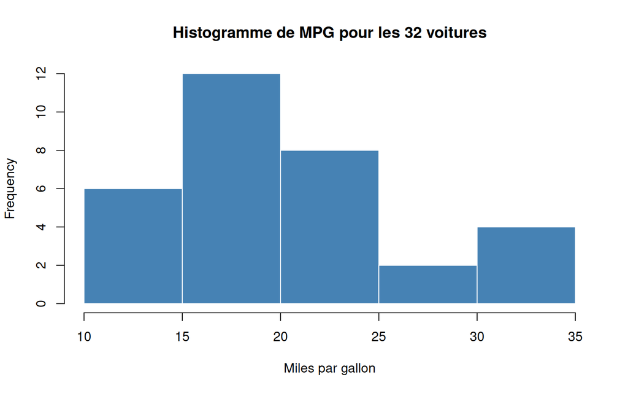

```r
dfcars$mpg |> hist(main = "Histogramme de MPG pour les 32 voitures",
                   xlab = "Miles par gallon", col = "steelblue", border = "white")
```

On peut ensuite filtrer les voitures très économiques (30 à 35 mpg) :

```r
dfcars |> filter(mpg >= 30 & mpg <= 35)
```

|  | mpg | cyl | disp | hp | drat | wt | qsec | vs | am | gear | carb |
| --- | --- | --- | --- | --- | --- | --- | --- | --- | --- | --- | --- |
| Fiat 128 | 32.4 | 4 | 78.7 | 66 | 4.08 | 2.200 | 19.47 | 1 | 1 | 4 | 1 |
| Honda Civic | 30.4 | 4 | 75.7 | 52 | 4.93 | 1.615 | 18.52 | 1 | 1 | 4 | 2 |
| Toyota Corolla | 33.9 | 4 | 71.1 | 65 | 4.22 | 1.835 | 19.90 | 1 | 1 | 4 | 1 |
| Lotus Europa | 30.4 | 4 | 95.1 | 113 | 3.77 | 1.513 | 16.90 | 1 | 1 | 5 | 2 |

### 1.3.2 Histogramme avec ggplot2

`ggplot2` offre une grammaire graphique déclarative : on décrit *ce que l’on veut voir*, et non *comment le dessiner*.

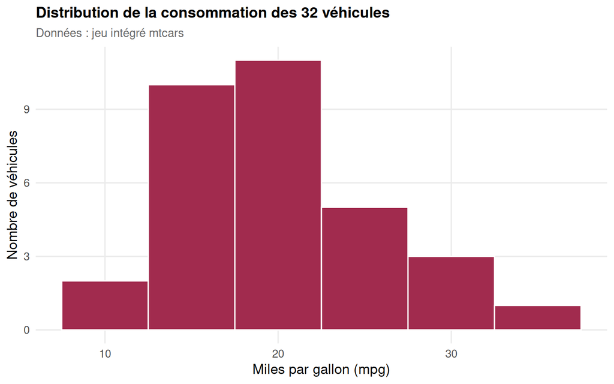

```r
dfcars |>
  ggplot(aes(x = mpg)) +
  geom_histogram(fill = "#a12b4e", binwidth = 5, color = "white") +
  labs(
    title    = "Distribution de la consommation des 32 véhicules",
    subtitle = "Données : jeu intégré mtcars",
    x        = "Miles par gallon (mpg)",
    y        = "Nombre de véhicules"
  )
```

**AvertissementPoint d’attention**

En version HTML, le thème ggplot2 est configuré globalement dans le chunk `setup` via `theme_set()`. Il n’est pas nécessaire d’ajouter `+ theme_minimal()` à chaque graphique-le thème s’applique automatiquement à tous les plots du document.

### 1.3.3 Exemple de représentation graphique en 3D avec Plotly

La bibliothèque `plotly` permet de créer des graphiques interactifs directement dans le navigateur, sans plugin. L’exemple ci-dessous construit un *histogramme 3D* à partir de 500 points tirés selon une loi normale bivariée $\mathcal{N}(0, I_2)$ : le plan $(x, y)$ est découpé en une grille $11 \times 11$, et chaque cellule est représentée par une barre 3D dont la hauteur correspond à l’effectif observé. La fonction auxiliaire `add_3Dbar()` construit chaque barre comme un prisme solide (`mesh3d`) défini par ses 8 sommets. Le graphique obtenu est *rotatif*, *zoomable* et *survol-actif* (infobulles au passage de la souris) — des fonctionnalités uniquement disponibles dans la version HTML du document.

**NoteVersion PDF**

Cette visualisation interactive n’est pas disponible dans la version PDF. Consulter la version HTML publiée sur albanpjy.github.io/ESD113/ pour interagir avec le graphique.

```r
library(plotly)
add_3Dbar <- function(p, x, y, z, width = 0.45){
 w <- width
 plotly::add_trace(
   p,
   type = "mesh3d",
   x = c(x-w, x-w, x+w, x+w, x-w, x-w, x+w, x+w),
   y = c(y-w, y+w, y+w, y-w, y-w, y+w, y+w, y-w),
   z = c(0, 0, 0, 0, z, z, z, z),
   i = c(7,0,0,0,4,4,2,6,4,0,3,7),
   j = c(3,4,1,2,5,6,5,5,0,1,2,2),
   k = c(0,7,2,3,6,7,1,2,5,5,7,6),
   opacity = 0.8,
   showscale = FALSE
 )
}
# exemple : histogramme 2D -> matrice de fréquences
x <- rnorm(500)
y <- rnorm(500)
bx <- seq(min(x), max(x), length.out = 12)
by <- seq(min(y), max(y), length.out = 12)
ix <- cut(x, breaks = bx, include.lowest = TRUE, labels = FALSE)
iy <- cut(y, breaks = by, include.lowest = TRUE, labels = FALSE)
tab <- table(ix, iy)
cx <- head(bx, -1) + diff(bx)/2
cy <- head(by, -1) + diff(by)/2
fig <- plot_ly()
for(i in seq_along(cx)){
 for(j in seq_along(cy)){
   z <- tab[i, j]
   if(z > 0){
     fig <- add_3Dbar(fig, cx[i], cy[j], z)
   }
 }
}
fig <- fig |>
 plotly::layout(
   scene = list(
     xaxis = list(title = "x"),
     yaxis = list(title = "y"),
     zaxis = list(title = "effectif")
   )
 )
fig
```

[interactive chart not shown]

# 2 Partie II-Projet Keno : analyse des données FDJ

## 2.1 Projet Keno-Analyse des données FDJ

### 2.1.1 Présentation du Keno

Le *Keno* est un jeu de tirage proposé par la Française des Jeux (FDJ). Dans la version étudiée ici, *16 boules* sont tirées parmi 56 numérotées de 1 à 56. Le joueur coche jusqu’à 10 numéros, et ses gains dépendent du nombre de numéros cochés figurant parmi les boules tirées.

### 2.1.2 Chargement des données

```r
keno_202511 <- read_delim(
  "keno_202511.csv",
  delim          = ";",
  escape_double  = FALSE,
  col_types      = cols(
    date_de_forclusion = col_skip(),
    ...23              = col_skip()
  ),
  trim_ws        = TRUE
)

keno_202511 <- keno_202511 |> select(-c(1, 19, 20, 21))

names(keno_202511)
```

```
#>  [1] "date_de_tirage" "boule1"         "boule2"         "boule3"
#>  [5] "boule4"         "boule5"         "boule6"         "boule7"
#>  [9] "boule8"         "boule9"         "boule10"        "boule11"
#> [13] "boule12"        "boule13"        "boule14"        "boule15"
#> [17] "boule16"
```

### 2.1.3 Pivot longer : restructuration des données

#### Le concept de pivot

Les données Keno arrivent au format *large* (wide) : chaque tirage est une ligne, avec 16 colonnes `boule1`, `boule2`, …, `boule16`. Pour les analyses statistiques, il est plus commode d’avoir un format *long* : une ligne par boule tirée.

```r
table4a <- tibble(
  country = c("A", "B", "C"),
  `1999`  = c(700,   37000,  212000),
  `2000`  = c(2000,  80000,  213000)
)
table4a
```

| country | 1999 | 2000 |
| --- | --- | --- |
| A | 700 | 2000 |
| B | 37000 | 80000 |
| C | 212000 | 213000 |

```r
table4a |>
  pivot_longer(
    cols      = 2:3,
    names_to  = "annee",
    values_to = "cas"
  )
```

| country | annee | cas |
| --- | --- | --- |
| A | 1999 | 700 |
| A | 2000 | 2000 |
| B | 1999 | 37000 |
| B | 2000 | 80000 |
| C | 1999 | 212000 |
| C | 2000 | 213000 |

#### Application au Keno

```r
keno_longer <- keno_202511 |>
  pivot_longer(
    cols            = 2:17,
    names_to        = "Boule",
    names_prefix    = "boule",
    values_to       = "Num_boule"
  ) |>
  mutate(
    Boule     = as.integer(Boule),
    Num_boule = as.integer(Num_boule)
  )

glimpse(keno_longer)
```

```
#> Rows: 1,600
#> Columns: 3
#> $ date_de_tirage <chr> "10/02/2026", "10/02/2026", "10/02/2026", "10/02/2026",…
#> $ Boule          <int> 1, 2, 3, 4, 5, 6, 7, 8, 9, 10, 11, 12, 13, 14, 15, 16, …
#> $ Num_boule      <int> 12, 13, 17, 20, 22, 23, 26, 27, 39, 42, 45, 48, 50, 52,…
```

### 2.1.4 Tableau de fréquence des boules

```r
freq_boules <- keno_longer |>
  dplyr::count(Num_boule, name = "frequence")

freq_boules |> filter(frequence == min(frequence))
```

| Num_boule | frequence |
| --- | --- |
| 5 | 17 |

### 2.1.5 Formatage des dates

```r
keno_202511 <- keno_202511 |>
  mutate(date_de_tirage = as.Date(date_de_tirage, format = "%d/%m/%Y"))

keno_202511 |>
  summarise(
    date_min = format(min(date_de_tirage), "%d/%m/%Y"),
    date_max = format(max(date_de_tirage), "%d/%m/%Y")
  )
```

| date_min | date_max |
| --- | --- |
| 03/11/2025 | 10/02/2026 |

### 2.1.6 Palmarès des numéros-style FDJ

Ce tableau s’inspire du *palmarès des numéros* du site FDJ. Pour chaque numéro de 1 à 56, on affiche le nombre de sorties, le pourcentage de présence et la date de dernière sortie. La boîte ci-dessous précise la formule de calcul utilisée et fournit la référence théorique pour interpréter correctement les valeurs affichées.

**NoteRappel théorique**

*Calcul du pourcentage de présence.* Pour chaque numéro $i \in \{1, \ldots, 56\}$, on note $S_i$ le nombre de tirages dans lesquels il est sorti. Avec $N$ tirages historiques disponibles, le pourcentage de présence du numéro $i$ est défini par :

$$\mathrm{Pct}_i = \frac{S_i}{N} \times 100$$

où $S_i$ est le nombre de sorties du numéro $i$ et $N$ le nombre total de tirages. Cette formule est strictement *identique au calcul officiel publié par la FDJ* sur sa page de statistiques Keno.

*Référence théorique.* À chaque tirage, 16 boules sont tirées parmi 56. La probabilité qu’un numéro donné figure dans un tirage est donc :

$$p_{\text{théo}} = \frac{16}{56} \approx 0{,}2857 = 28{,}57\,\%$$

*Lecture du tableau.* Un numéro affichant un pourcentage proche de *28,57 %* est conforme à la loi théorique. Un écart vers le haut indique un numéro *sur-représenté* sur la période, vers le bas un numéro *sous-représenté*. Ces écarts relèvent de la fluctuation d’échantillonnage-ils n’ont aucune valeur prédictive pour les tirages futurs.

```r
df_keno <- read_delim("keno_202511.csv", delim = ";", show_col_types = FALSE)

## ── Correction robuste du décompte des tirages ──────────────────────────────
## nrow(df_keno) peut surestimer si le CSV contient des lignes parasites.
## On compte le nombre de dates de tirage VALIDES et DISTINCTES après parsing.
total_tirages <- df_keno |>
  mutate(date_dt = dmy(date_de_tirage)) |>
  filter(!is.na(date_dt)) |>
  distinct(date_dt) |>
  nrow()

message("Nombre de tirages distincts retenus : ", total_tirages)

freq_boules_fdj <- df_keno |>
  pivot_longer(
    cols     = matches("^boule[0-9]+$"),
    names_to = "position",
    values_to = "Num_boule"
  ) |>
  mutate(
    date_dt   = dmy(date_de_tirage),
    Num_boule = as.integer(Num_boule)
  ) |>
  filter(!is.na(date_dt), !is.na(Num_boule)) |>
  group_by(Num_boule) |>
  summarise(
    Sorties  = n(),
    ## Pct = Sorties / total_tirages * 100 (ex. 30 sorties sur 100 → 30.00 %)
    Pct      = (n() / total_tirages) * 100,
    Derniere = max(date_dt, na.rm = TRUE)
  ) |>
  arrange(Num_boule)

fdj_style <- tags$style(HTML("
  .fdj-title { font-family: sans-serif; font-size: 1.2em; font-weight: bold;
    margin-bottom: 5px; color: #000; }
  .fdj-subtitle { font-family: sans-serif; font-size: 0.9em; color: #666; margin-bottom: 20px; }
  .fdj-table { font-family: sans-serif !important; border-collapse: collapse !important;
    width: 100% !important; margin-bottom: 30px; }
  .fdj-table thead th { border-bottom: 2px solid #f2f2f2 !important; padding: 15px !important;
    font-weight: bold; color: #000; background-color: white !important; }
  .fdj-table td { border-bottom: 1px solid #f2f2f2 !important; padding: 12px !important;
    font-size: 14px; vertical-align: middle; background-color: white !important; }
  .fdj-table tr:hover { background-color: #f9f9f9 !important; }
  .dot  { color: #a12b4e; margin-left: 10px; font-size: 18px; }
  .num-bold { font-weight: bold; color: #000; }
"))

header_html <- HTML('
  <div class="fdj-title">Palmarès des numéros</div>
  <div class="fdj-subtitle">Statistiques calculées sur la base des tirages du midi et du soir.</div>
')

tableau_final <- freq_boules_fdj |>
  mutate(
    Num_boule = paste0('<span class="num-bold">', Num_boule, '</span>',
                       '<span class="dot">●</span>'),
    Pct      = paste0(sprintf("%.2f", Pct), " %"),
    Derniere = format(Derniere, "%d/%m/%y")
  ) |>
  select(
    `Numéros`           = Num_boule,
    `Nombre de sorties` = Sorties,
    `% de sorties*`     = Pct,
    `Dernière sortie`   = Derniere
  ) |>
  kable(escape = FALSE, align = "lccc", format = "html",
        table.attr = 'class="fdj-table"')

tagList(
  fdj_style,
  header_html,
  HTML(tableau_final),
  tags$p(style = "font-size: 0.8em; color: #666; font-family: sans-serif;",
         paste0("* Le pourcentage de sorties est calculé par rapport au nombre de tirages valides distincts ",
                "(N = ", total_tirages, "). Formule : sorties / N × 100."))
)
```

Palmarès des numéros

Statistiques calculées sur la base des tirages du midi et du soir.

| Numéros | Nombre de sorties | % de sorties* | Dernière sortie |
| --- | --- | --- | --- |
| 1● | 30 | 30.00 % | 09/02/26 |
| 2● | 26 | 26.00 % | 08/02/26 |
| 3● | 28 | 28.00 % | 09/02/26 |
| 4● | 32 | 32.00 % | 09/02/26 |
| 5● | 17 | 17.00 % | 02/02/26 |
| 6● | 21 | 21.00 % | 05/02/26 |
| 7● | 37 | 37.00 % | 08/02/26 |
| 8● | 23 | 23.00 % | 04/02/26 |
| 9● | 33 | 33.00 % | 09/02/26 |
| 10● | 30 | 30.00 % | 02/02/26 |
| 11● | 28 | 28.00 % | 09/02/26 |
| 12● | 28 | 28.00 % | 10/02/26 |
| 13● | 38 | 38.00 % | 10/02/26 |
| 14● | 35 | 35.00 % | 09/02/26 |
| 15● | 21 | 21.00 % | 09/02/26 |
| 16● | 23 | 23.00 % | 06/02/26 |
| 17● | 33 | 33.00 % | 10/02/26 |
| 18● | 19 | 19.00 % | 04/02/26 |
| 19● | 38 | 38.00 % | 08/02/26 |
| 20● | 24 | 24.00 % | 10/02/26 |
| 21● | 29 | 29.00 % | 08/02/26 |
| 22● | 20 | 20.00 % | 10/02/26 |
| 23● | 29 | 29.00 % | 10/02/26 |
| 24● | 29 | 29.00 % | 02/02/26 |
| 25● | 27 | 27.00 % | 09/02/26 |
| 26● | 28 | 28.00 % | 10/02/26 |
| 27● | 36 | 36.00 % | 10/02/26 |
| 28● | 33 | 33.00 % | 05/02/26 |
| 29● | 26 | 26.00 % | 08/02/26 |
| 30● | 35 | 35.00 % | 06/02/26 |
| 31● | 29 | 29.00 % | 09/02/26 |
| 32● | 24 | 24.00 % | 30/01/26 |
| 33● | 24 | 24.00 % | 28/01/26 |
| 34● | 25 | 25.00 % | 02/02/26 |
| 35● | 29 | 29.00 % | 08/02/26 |
| 36● | 24 | 24.00 % | 09/02/26 |
| 37● | 29 | 29.00 % | 03/02/26 |
| 38● | 31 | 31.00 % | 05/02/26 |
| 39● | 27 | 27.00 % | 10/02/26 |
| 40● | 27 | 27.00 % | 08/02/26 |
| 41● | 38 | 38.00 % | 06/02/26 |
| 42● | 30 | 30.00 % | 10/02/26 |
| 43● | 25 | 25.00 % | 08/02/26 |
| 44● | 30 | 30.00 % | 08/02/26 |
| 45● | 25 | 25.00 % | 10/02/26 |
| 46● | 32 | 32.00 % | 09/02/26 |
| 47● | 31 | 31.00 % | 02/02/26 |
| 48● | 30 | 30.00 % | 10/02/26 |
| 49● | 32 | 32.00 % | 07/02/26 |
| 50● | 30 | 30.00 % | 10/02/26 |
| 51● | 30 | 30.00 % | 08/02/26 |
| 52● | 29 | 29.00 % | 10/02/26 |
| 53● | 32 | 32.00 % | 09/02/26 |
| 54● | 24 | 24.00 % | 04/02/26 |
| 55● | 33 | 33.00 % | 10/02/26 |
| 56● | 24 | 24.00 % | 10/02/26 |

* Le pourcentage de sorties est calculé par rapport au nombre de tirages valides distincts (N = 100). Formule : sorties / N × 100.

### 2.1.7 Statistiques sur le format long

```r
keno_long <- keno_202511 |>
  pivot_longer(
    cols            = boule1:boule16,
    names_to        = "boule",
    names_prefix    = "boule",
    names_transform = list(boule = as.integer),
    values_to       = "numero"
  )

table_freq <- keno_long |>
  dplyr::count(numero, name = "Nombre de sorties") |>
  complete(numero = 1:56, fill = list(`Nombre de sorties` = 0)) |>
  arrange(numero)

table_freq |>
  kable(col.names = c("Numéro", "Nombre de sorties"),
        caption   = "Fréquence d'apparition des numéros (Keno — données FDJ)") |>
  kable_styling(bootstrap_options = c("striped", "hover", "condensed"), full_width = FALSE)
```

Fréquence d'apparition des numéros (Keno — données FDJ)

| Numéro | Nombre de sorties |
| --- | --- |
| 1 | 30 |
| 2 | 26 |
| 3 | 28 |
| 4 | 32 |
| 5 | 17 |
| 6 | 21 |
| 7 | 37 |
| 8 | 23 |
| 9 | 33 |
| 10 | 30 |
| 11 | 28 |
| 12 | 28 |
| 13 | 38 |
| 14 | 35 |
| 15 | 21 |
| 16 | 23 |
| 17 | 33 |
| 18 | 19 |
| 19 | 38 |
| 20 | 24 |
| 21 | 29 |
| 22 | 20 |
| 23 | 29 |
| 24 | 29 |
| 25 | 27 |
| 26 | 28 |
| 27 | 36 |
| 28 | 33 |
| 29 | 26 |
| 30 | 35 |
| 31 | 29 |
| 32 | 24 |
| 33 | 24 |
| 34 | 25 |
| 35 | 29 |
| 36 | 24 |
| 37 | 29 |
| 38 | 31 |
| 39 | 27 |
| 40 | 27 |
| 41 | 38 |
| 42 | 30 |
| 43 | 25 |
| 44 | 30 |
| 45 | 25 |
| 46 | 32 |
| 47 | 31 |
| 48 | 30 |
| 49 | 32 |
| 50 | 30 |
| 51 | 30 |
| 52 | 29 |
| 53 | 32 |
| 54 | 24 |
| 55 | 33 |
| 56 | 24 |

## 2.2 Visualisations graphiques du Keno

### 2.2.1 Histogramme des fréquences

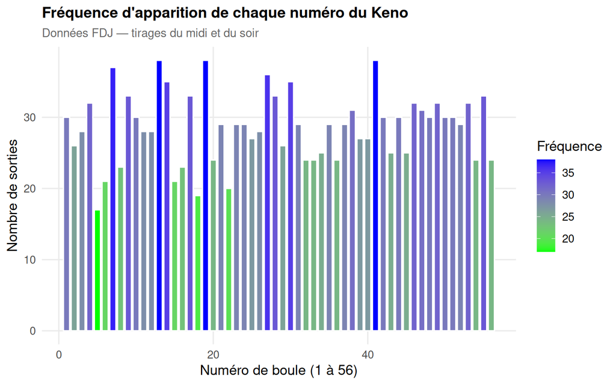

```r
freq_boules_plot <- keno_long |>
  dplyr::count(numero, name = "frequence") |>
  complete(numero = 1:56, fill = list(frequence = 0)) |>
  arrange(numero)

freq_boules_plot |>
  ggplot(aes(x = numero, y = frequence, fill = frequence)) +
  geom_bar(stat = "identity", color = "white", width = 0.8) +
  scale_fill_gradient(low = "green", high = "blue") +
  labs(
    title    = "Fréquence d'apparition de chaque numéro du Keno",
    subtitle = "Données FDJ — tirages du midi et du soir",
    x        = "Numéro de boule (1 à 56)",
    y        = "Nombre de sorties",
    fill     = "Fréquence"
  ) +
  theme(legend.position = "right")
```

### 2.2.2 Graphique circulaire (diagramme en rose)

Ce graphique polaire enroule les 56 numéros autour d’un axe circulaire, permettant de visualiser d’un coup d’œil l’uniformité des tirages :

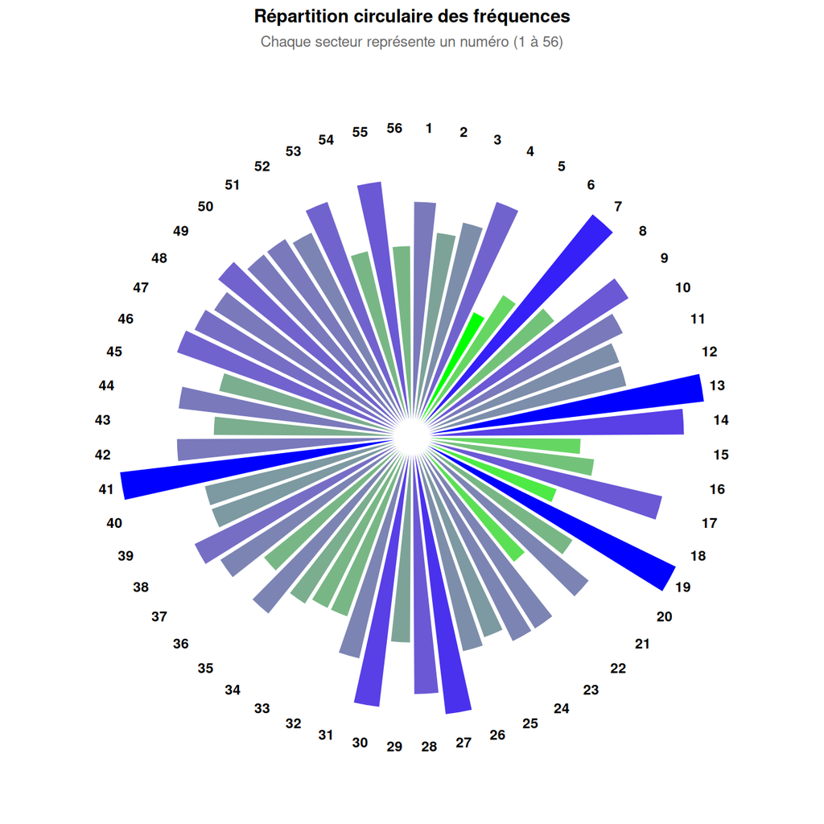

```r
freq_boules_plot |>
  ggplot(aes(
    x    = reorder(as.factor(numero), as.numeric(numero)),
    y    = frequence,
    fill = frequence
  )) +
  geom_bar(stat = "identity", show.legend = FALSE, color = "white") +
  coord_polar(theta = "x", clip = "off") +
  geom_text(aes(y = 40, label = numero), color = "black", size = 3, fontface = "bold") +
  ylim(-2, max(freq_boules_plot$frequence) + 2) +
  scale_fill_gradient(low = "green", high = "blue") +
  labs(title    = "Répartition circulaire des fréquences",
       subtitle = "Chaque secteur représente un numéro (1 à 56)") +
  theme_void() +
  theme(plot.title    = element_text(face = "bold", hjust = 0.5, size = 11),
        plot.subtitle = element_text(hjust = 0.5, color = "grey40", size = 9),
        plot.margin   = margin(0, 0, 0, 0, "pt"),
        aspect.ratio  = 1)
```

## 2.3 Modélisation probabiliste du Keno

### 2.3.1 La loi hypergéométrique

**NoteRappel théorique**

Le Keno est un tirage *sans remise* : les boules ne sont pas replacées dans l’urne. La distribution de probabilité adaptée est la *loi hypergéométrique*.

Code LaTeX de la formule :

```latex
$$P(X = x) = \frac{\binom{K}{x}\binom{N-K}{n-x}}{\binom{N}{n}}$$
```

$$P(X = x) = \frac{\binom{K}{x}\binom{N-K}{n-x}}{\binom{N}{n}}$$

avec : $N = 56$ (taille de l’urne), $K = 16$ (boules tirées par le Keno), $n = 10$ (numéros cochés par le joueur), $x$ (nombre de bons numéros).

La fonction R correspondante est `dhyper(x, m, n, k)` où `m` est le nombre de boules « succès » dans l’urne, `n` le nombre de boules « échec », et `k` le nombre de tirages.

### 2.3.2 Calcul des probabilités de gain

```r
tibble(
  x      = 0:10,
  `p(x)` = dhyper(0:10, m = 16, n = 40, k = 10),
  chance = round(1 / `p(x)`)
)
```

| x | p(x) | chance |
| --- | --- | --- |
| 0 | 2.380597e-02 | 42 |
| 1 | 1.228695e-01 | 8 |
| 2 | 2.591779e-01 | 4 |
| 3 | 2.932114e-01 | 3 |
| 4 | 1.961929e-01 | 5 |
| 5 | 8.071938e-02 | 12 |
| 6 | 2.055354e-02 | 49 |
| 7 | 3.174293e-03 | 315 |
| 8 | 2.819273e-04 | 3547 |
| 9 | 1.285139e-05 | 77813 |

[output cut: 1 more lines]

### 2.3.3 Tableau des gains officiels FDJ

```r
tableau_gains <- tibble(
  x       = 0:10,
  `p(x)`  = dhyper(x, m = 16, n = 40, k = 10)
) |>
  arrange(desc(x)) |>
  filter(!x %in% 1:4) |>
  mutate(`g(x) en €` = c(200000, 2000, 150, 15, 5, 2, 2), .after = x)

tableau_gains |>
  kable(digits = 6,
        caption   = "Gains officiels FDJ et probabilités associées (mise de 1 €, 10 numéros cochés)",
        col.names = c("Bonnes boules (x)", "Gain g(x) en €", "Probabilité p(x)")) |>
  kable_styling(bootstrap_options = c("striped", "hover"), full_width = FALSE) |>
  row_spec(1, bold = TRUE, color = "white", background = "#a12b4e")
```

| Bonnes boules (x) | Gain g(x) en € | Probabilité p(x) |
| --- | --- | --- |
| 10 | 200000 | 0.000000 |
| 9 | 2000 | 0.000013 |
| 8 | 150 | 0.000282 |
| 7 | 15 | 0.003174 |
| 6 | 5 | 0.020554 |
| 5 | 2 | 0.080719 |
| 0 | 2 | 0.023806 |

## 2.4 Référence officielle FDJ : tableau complet des gains

### 2.4.1 Les tableaux de gains officiels

Les probabilités et gains présentés dans cette section sont calculés à partir des règles officielles du Keno FDJ. Les sources officielles sont consultables en ligne :

- *Probabilités et chances de gagner* : [fdj.fr — Quelles sont les chances de gagner au Kéno ?](https://www.fdj.fr/mag/questions/article-quelles-les-chances-de-gagner-keno-190326)
- *Statistiques officielles des tirages* : [fdj.fr — Kéno Statistiques](https://www.fdj.fr/jeux-de-tirage/keno/statistiques)

**AvertissementNote sur le modèle utilisé**

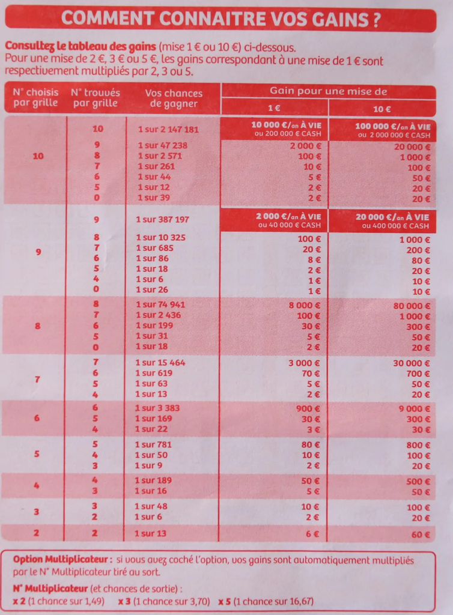

*Tableau officiel FDJ — toutes grilles de 2 à 10 numéros (version 2020)*

### 2.4.2 Construction de la table complète des gains FDJ

```r
## ── Paramètres du Keno FDJ — modèle des données historiques ─────────────────
## Les données keno_202511.csv correspondent à l'ancienne version du Keno :
## 16 boules tirées parmi 56.  Toutes les probabilités sont calculées sur ce
## modèle pour rester cohérentes avec les analyses empiriques du document.
## Note : la version en vigueur depuis 2020 tire 20 boules parmi 70 ; les gains
##        officiels affichés sont identiques, mais les probabilités diffèrent.
N_keno <- 56   # taille de l'urne (version historique — données keno_202511.csv)
K_keno <- 16   # boules tirées par tirage (version historique)

## Table des gains officiels FDJ (mise 1 €) — source : article 8 du règlement
## FDJ (modèle 16/56 correspondant aux données disponibles).
gains_fdj <- list(
  `10` = list(`10` = 200000, `9` = 2000, `8` = 150, `7` = 15,
              `6`  = 5,      `5` = 2,    `0` = 2),
  `9`  = list(`9`  = 30000,  `8` = 100,  `7` = 25,  `6` = 8,
              `5`  = 2,      `4` = 1,    `0` = 2),
  `8`  = list(`8`  = 8000,   `7` = 100,  `6` = 30,  `5` = 5,  `0` = 2),
  `7`  = list(`7`  = 3000,   `6` = 90,   `5` = 5,   `4` = 2),
  `6`  = list(`6`  = 900,    `5` = 30,   `4` = 3),
  `5`  = list(`5`  = 80,     `4` = 10,   `3` = 2),
  `4`  = list(`4`  = 70,     `3` = 3),
  `3`  = list(`3`  = 10,     `2` = 2),
  `2`  = list(`2`  = 6)
)

message("Table des gains FDJ chargée : ", length(gains_fdj), " grilles définies (2 à 10 numéros).")
```

```r
df_gains_long <- purrr::imap_dfr(gains_fdj, function(gains_grille, n_coches_chr) {
  n <- as.integer(n_coches_chr)
  purrr::imap_dfr(gains_grille, function(gain, n_trouves_chr) {
    x <- as.integer(n_trouves_chr)
    p <- dhyper(x, m = K_keno, n = N_keno - K_keno, k = n)
    tibble(
      n_coches   = n,
      n_trouves  = x,
      prob       = p,
      chance     = if (p > 0) round(1 / p) else NA_real_,
      gain_1eur  = gain,
      gain_10eur = gain * 10
    )
  })
}) |>
  arrange(desc(n_coches), desc(n_trouves))

message("Tableau long construit : ", nrow(df_gains_long), " lignes.")
```

```r
df_gains_long |>
  filter(n_coches == 10) |>
  select(
    `N° trouvés`      = n_trouves,
    `Probabilité`     = prob,
    `1 chance sur...` = chance,
    `Gain (1 €)`      = gain_1eur,
    `Gain (10 €)`     = gain_10eur
  ) |>
  kable(
    digits      = 7,
    format.args = list(big.mark = " "),
    caption     = "Grille à 10 numéros cochés — probabilités et gains officiels FDJ (16 boules sur 56, mise 1 euro)"
  ) |>
  kable_styling(
    bootstrap_options = c("striped", "hover", "condensed"),
    font_size         = 10,
    full_width        = FALSE
  ) |>
  row_spec(1, bold = TRUE, color = "white", background = "#a12b4e") |>
  column_spec(4, bold = TRUE)
```

| N° trouvés | Probabilité | 1 chance sur... | Gain (1 €) | Gain (10 €) |
| --- | --- | --- | --- | --- |
| 10 | 0.0000002 | 4 446 435 | 200 000 | 2 000 000 |
| 9 | 0.0000129 | 77 813 | 2 000 | 20 000 |
| 8 | 0.0002819 | 3 547 | 150 | 1 500 |
| 7 | 0.0031743 | 315 | 15 | 150 |
| 6 | 0.0205535 | 49 | 5 | 50 |
| 5 | 0.0807194 | 12 | 2 | 20 |
| 0 | 0.0238060 | 42 | 2 | 20 |

```r
groupes <- df_gains_long |>
  mutate(row_id = row_number()) |>
  group_by(n_coches) |>
  summarise(debut = min(row_id), fin = max(row_id), .groups = "drop") |>
  arrange(desc(n_coches))

tbl_complet <- df_gains_long |>
  mutate(
    prob_fmt   = formatC(prob,   format = "e", digits = 3),
    chance_fmt = formatC(chance, format = "fg", big.mark = " ",
                         flag = "#") |> stringr::str_trim(),
    gain_fmt   = paste0(formatC(gain_1eur, format = "fg", big.mark = " "), " €")
  ) |>
  select(
    `Grille`       = n_coches,
    `N° trouvés`   = n_trouves,
    `p(x)`         = prob_fmt,
    `1 chance sur` = chance_fmt,
    `Gain (1 €)`   = gain_fmt
  )

tbl_obj <- tbl_complet |>
  kable(
    align   = c("c","c","r","r","r"),
    caption = "Table complète des gains FDJ — toutes grilles de 2 à 10 numéros cochés (16 boules tirées sur 56, mise 1 euro)",
    linesep = ""
  ) |>
  kable_styling(
    bootstrap_options = c("striped", "hover", "condensed"),
    font_size         = 9,
    full_width        = FALSE
  )

for (i in seq_len(nrow(groupes))) {
  tbl_obj <- tbl_obj |>
    pack_rows(
      paste0(groupes$n_coches[i], " numéros cochés"),
      groupes$debut[i],
      groupes$fin[i]
    )
}

tbl_obj
```

Table complète des gains FDJ — toutes grilles de 2 à 10 numéros cochés (16 boules tirées sur 56, mise 1 euro)

| Grille | N° trouvés | p(x) | 1 chance sur | Gain (1 €) |
| --- | --- | --- | --- | --- |
| **10 numéros cochés** |  |  |  |  |
| 10 | 10 | 2.249e-07 | 4 446 435 | 200 000 € |
| 10 | 9 | 1.285e-05 | 77 813 | 2 000 € |
| 10 | 8 | 2.819e-04 | 3 547 | 150 € |
| 10 | 7 | 3.174e-03 | 315.0 | 15 € |
| 10 | 6 | 2.055e-02 | 49.00 | 5 € |
| 10 | 5 | 8.072e-02 | 12.00 | 2 € |
| 10 | 0 | 2.381e-02 | 42.00 | 2 € |
| **9 numéros cochés** |  |  |  |  |
| 9 | 9 | 1.510e-06 | 662 235 | 30 000 € |
| 9 | 8 | 6.795e-05 | 14 716 | 100 € |
| 9 | 7 | 1.178e-03 | 849.0 | 25 € |
| 9 | 6 | 1.044e-02 | 96.00 | 8 € |
| 9 | 5 | 5.269e-02 | 19.00 | 2 € |
| 9 | 4 | 1.581e-01 | 6.000 | 1 € |
| 9 | 0 | 3.609e-02 | 28.00 | 2 € |
| **8 numéros cochés** |  |  |  |  |
| 8 | 8 | 9.060e-06 | 110 373 | 8 000 € |
| 8 | 7 | 3.221e-04 | 3 104 | 100 € |
| 8 | 6 | 4.397e-03 | 227.0 | 30 € |
| 8 | 5 | 3.038e-02 | 33.00 | 5 € |
| 8 | 0 | 5.414e-02 | 18.00 | 2 € |
| **7 numéros cochés** |  |  |  |  |
| 7 | 7 | 4.933e-05 | 20 272 | 3 000 € |
| 7 | 6 | 1.381e-03 | 724.0 | 90 € |
| 7 | 5 | 1.469e-02 | 68.00 | 5 € |
| 7 | 4 | 7.753e-02 | 13.00 | 2 € |
| **6 numéros cochés** |  |  |  |  |
| 6 | 6 | 2.466e-04 | 4 055 | 900 € |
| 6 | 5 | 5.381e-03 | 186.0 | 30 € |
| 6 | 4 | 4.372e-02 | 23.00 | 3 € |
| **5 numéros cochés** |  |  |  |  |
| 5 | 5 | 1.144e-03 | 874.0 | 80 € |
| 5 | 4 | 1.906e-02 | 52.00 | 10 € |
| 5 | 3 | 1.144e-01 | 9.000 | 2 € |
| **4 numéros cochés** |  |  |  |  |
| 4 | 4 | 4.955e-03 | 202.0 | 70 € |
| 4 | 3 | 6.099e-02 | 16.00 | 3 € |
| **3 numéros cochés** |  |  |  |  |
| 3 | 3 | 2.020e-02 | 49.00 | 10 € |
| 3 | 2 | 1.732e-01 | 6.000 | 2 € |
| **2 numéros cochés** |  |  |  |  |
| 2 | 2 | 7.792e-02 | 13.00 | 6 € |

### 2.4.3 Espérances de gain par grille

**NoteRappel théorique**

Pour chaque grille (nombre de numéros cochés $n$), l’espérance de gain se calcule en sommant les gains pondérés par leurs probabilités, sur toutes les combinaisons gagnantes :

Code LaTeX de la formule :

```latex
$$E_n[G] = \sum_{x \in \mathcal{G}_n} g(x) \cdot p(x)$$
```

$$E_n[G] = \sum_{x \in \mathcal{G}_n} g(x) \cdot p(x)$$

où $\mathcal{G}_n$ est l’ensemble des valeurs de $x$ donnant lieu à un gain pour la grille $n$.

```r
df_esperances <- df_gains_long |>
  group_by(n_coches) |>
  summarise(
    esperance = sum(gain_1eur * prob, na.rm = TRUE),
    .groups   = "drop"
  ) |>
  mutate(
    trj_pct   = round(esperance * 100, 2),
    perte_moy = round(1 - esperance, 4)
  ) |>
  arrange(desc(n_coches))

df_esperances |>
  select(
    `N° cochés`                 = n_coches,
    `Espérance E[G]`            = esperance,
    `TRJ (%)`                   = trj_pct,
    `Perte moy. / tirage (EUR)` = perte_moy
  ) |>
  kable(
    digits   = 4,
    caption  = "Espérance de gain et taux de retour joueur (TRJ) par grille — Keno FDJ (mise 1 euro)"
  ) |>
  kable_styling(
    bootstrap_options = c("striped", "hover", "condensed"),
    font_size         = 10,
    full_width        = FALSE
  ) |>
  column_spec(3, bold = TRUE, color = "white",
              background = spec_color(df_esperances$trj_pct,
                                      option = "C", direction = -1,
                                      begin  = 0.3, end = 0.9))
```

Espérance de gain et taux de retour joueur (TRJ) par grille — Keno FDJ (mise 1 euro)

| N° cochés | Espérance E[G] | TRJ (%) | Perte moy. / tirage (EUR) |
| --- | --- | --- | --- |
| 10 | 0.4724 | 47.24 | 0.5276 |
| 9 | 0.5007 | 50.07 | 0.4993 |
| 8 | 0.4968 | 49.68 | 0.5032 |
| 7 | 0.5008 | 50.08 | 0.4992 |
| 6 | 0.5146 | 51.46 | 0.4854 |
| 5 | 0.5108 | 51.08 | 0.4892 |
| 4 | 0.5298 | 52.98 | 0.4702 |
| 3 | 0.5483 | 54.83 | 0.4517 |
| 2 | 0.4675 | 46.75 | 0.5325 |

**AstuceÀ retenir**

Le *taux de retour joueur (TRJ)* est la fraction de la mise que le joueur récupère *en moyenne* sur un très grand nombre de parties. Un TRJ de 50 % signifie que pour 1 € joué, le joueur récupère en moyenne 0,50 € et perd donc 0,50 €. Ce taux est encadré réglementairement par l’ANJ (Autorité Nationale des Jeux, qui a succédé à l’ARJEL en 2020).

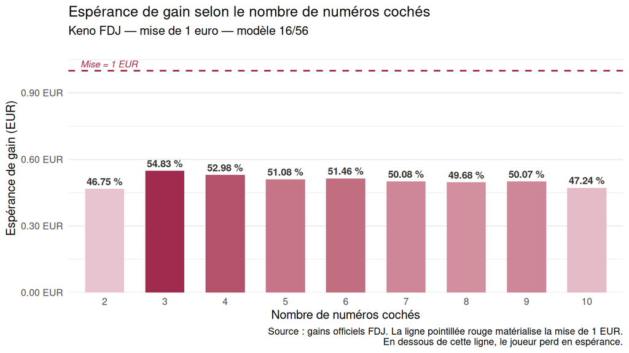

Espérance de gain selon le nombre de numéros cochés — Keno FDJ (mise 1 euro, modèle 16/56). Toutes les barres restent sous la ligne pointillée rouge, confirmant que l’espérance est toujours négative pour le joueur.

```r
df_esperances |>
  ggplot(aes(x = factor(n_coches), y = esperance)) +
  geom_col(aes(fill = esperance), width = 0.65, show.legend = FALSE) +
  geom_hline(yintercept = 1, linetype = "dashed",
             color = "#a12b4e", linewidth = 0.7) +
  geom_text(aes(label = paste0(trj_pct, " %")),
            vjust = -0.5, size = 3.2, fontface = "bold", color = "gray20") +
  scale_fill_gradient(low = "#e8c4d0", high = "#a12b4e") +
  scale_y_continuous(
    labels = scales::label_number(suffix = " EUR", accuracy = 0.01),
    limits = c(0, 1.10),
    expand = expansion(mult = c(0, 0.02))
  ) +
  annotate("text", x = 0.6, y = 1.03, label = "Mise = 1 EUR",
           color = "#a12b4e", size = 3, hjust = 0, fontface = "italic") +
  labs(
    title    = "Espérance de gain selon le nombre de numéros cochés",
    subtitle = "Keno FDJ — mise de 1 euro — modèle 16/56",
    x        = "Nombre de numéros cochés",
    y        = "Espérance de gain (EUR)",
    caption  = "Source : gains officiels FDJ. La ligne pointillée rouge matérialise la mise de 1 EUR.\nEn dessous de cette ligne, le joueur perd en espérance."
  ) +
  theme_minimal() +
  theme(panel.grid.major.x = element_blank())
```

**AvertissementLecture du graphique**

Toutes les barres sont *sous la ligne pointillée rouge* (la mise de 1 €), confirmant que l’*espérance de gain est toujours négative pour le joueur*, quelle que soit la grille choisie. Le TRJ affiché au-dessus de chaque barre (en % de la mise) montre que la FDJ reverse entre 47 % et 55 % de la mise en gains — la différence constituant la marge opératrice.

## 2.5 Espérance de gain

### 2.5.1 Définition et formule

**NoteRappel théorique**

L’*espérance mathématique* de gain est la valeur moyenne que le joueur peut espérer gagner par tirage. Elle se calcule comme la somme des gains pondérés par leurs probabilités :

Code LaTeX de la formule :

```latex
$$E[G] = \sum_{x=0}^{10} g(x) \cdot p(x)$$
```

$$E[G] = \sum_{x=0}^{10} g(x) \cdot p(x)$$

où $g(x)$ est le gain pour $x$ bonnes boules, et $p(x)$ la probabilité d’en obtenir exactement $x$.

### 2.5.2 Calcul avec R

```r
result <- tibble(
  x      = 0:10,
  `p(x)` = dhyper(x, m = 16, n = 40, k = 10)
) |>
  arrange(desc(x)) |>
  filter(!x %in% 1:4) |>
  mutate(`g(x)` = c(200000, 2000, 150, 15, 5, 2, 2), .after = x)

esperance <- result |>
  summarise(esperance = sum(`g(x)` * `p(x)`))

esperance
```

| esperance |
| --- |
| 0.4724045 |

> *Interprétation :* Pour une mise de 1 €, l’espérance de gain est d’environ 0.472 €. Cela signifie que le joueur perd en moyenne 0.528 € à chaque tirage — ce qui traduit la marge de la FDJ.

**AvertissementPoint d’attention**

L’espérance de gain est inférieure à 1 euro (la mise). Cela signifie que le joueur perd en moyenne de l’argent à chaque tirage-c’est la *marge* intégrée par la FDJ dans le jeu. Ce résultat est fondamental en théorie des jeux et illustre pourquoi les jeux d’argent ne peuvent pas être des stratégies de gain à long terme.

## 2.6 Simulations de Monte-Carlo

### 2.6.1 Principe

La *simulation de Monte-Carlo* est une méthode numérique qui consiste à simuler un grand nombre de tirages aléatoires pour estimer des probabilités ou des distributions.

### 2.6.2 Premier exemple : simulation simple

```r
set.seed(123)

numeros <- c()
for (t in 1:100) {
  numeros <- c(numeros, sample(1:56, 16, replace = FALSE))
}
table(numeros) |> min()
```

```
#> [1] 20
```

La même simulation, plus élégamment avec `replicate()` :

```r
set.seed(123)
numeros_simu <- as.vector(replicate(100, sample(1:56, 16, replace = FALSE)))
table(numeros_simu) |> min()
```

```
#> [1] 20
```

### 2.6.3 Estimation d’une probabilité par Monte-Carlo

On répète l’expérience *N = 100 fois* pour estimer la probabilité qu’un numéro sorte 17 fois ou moins sur 100 tirages :

```r
set.seed(123)
N <- 100

valmin <- replicate(N, {
  tirages <- replicate(100, sample(1:56, 16, replace = FALSE))
  counts  <- table(factor(as.vector(tirages), levels = 1:56))
  min(counts)
})

cat("Probabilité estimée P(min ≤ 17) =", sum(valmin <= 17) / N)
```

```
#> Probabilité estimée P(min ≤ 17) = 0.26
```

### 2.6.4 Simulation de Monte-Carlo à grande échelle (1 000 itérations)

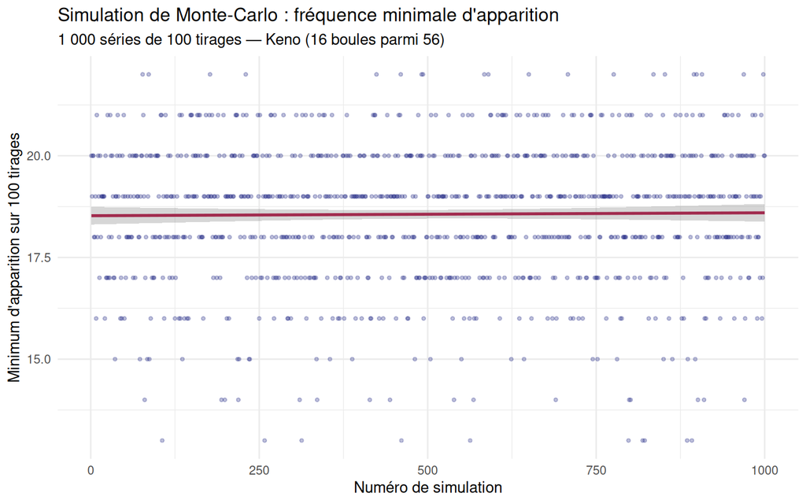

```r
set.seed(123)
n_simulations     <- 1000
tirages_par_serie <- 100

simuler_min <- function() {
  resultats <- replicate(tirages_par_serie, sample(1:56, 16, replace = FALSE))
  counts    <- table(factor(resultats, levels = 1:56))
  return(min(counts))
}

simus    <- replicate(n_simulations, simuler_min())
df_simus <- data.frame(id = 1:n_simulations, val_min = simus)

ggplot(df_simus, aes(x = id, y = val_min)) +
  geom_point(alpha = 0.3, color = "#282D87", size = 0.9) +
  geom_smooth(method = "lm", color = "#a12b4e", se = TRUE) +
  labs(
    title    = "Simulation de Monte-Carlo : fréquence minimale d'apparition",
    subtitle = "1 000 séries de 100 tirages — Keno (16 boules parmi 56)",
    x        = "Numéro de simulation",
    y        = "Minimum d'apparition sur 100 tirages"
  ) +
  theme_minimal()
```

```r
seuil_critique <- mean(simus)
cat("En moyenne, sur 100 tirages, le numéro le moins sorti apparaît",
    round(seuil_critique, 1), "fois.")
```

```
#> En moyenne, sur 100 tirages, le numéro le moins sorti apparaît 18.6 fois.
```

**AstuceÀ retenir**

La droite de régression (quasiment horizontale) confirme que le processus est *stationnaire* : le minimum d’apparition ne dérive pas au fil des simulations. C’est une propriété attendue d’un tirage véritablement aléatoire et uniforme.

# 3 Partie III-Méthodes de clustering

## 3.1 Introduction au clustering

Ce volet a été réalisé dans le cadre de la même unité d’enseignement *ESD113*. L’objectif principal est de reproduire et d’adapter le [code R](https://www.stats.gla.ac.uk/~nd29c/Software/ClusterReviewCode.R) utilisé dans l’article de référence *“A Survey of Popular R Packages for Cluster Analysis”* (Flynt et Dean 2016).

### 3.1.1 Qu’est-ce que le clustering ?

Imaginez une carte sur laquelle figurent des centaines de villes représentées uniquement par leurs coordonnées géographiques (latitude, longitude) — deux variables *quantitatives continues*. Votre mission : regrouper ces villes en régions *sans connaître à l’avance* les frontières administratives. Naturellement, vous mesureriez les distances physiques et réuniriez les villes proches les unes des autres. Sans le savoir, vous appliquez le principe de l’algorithme K-means : minimiser la distance euclidienne entre chaque point et le centre de son groupe (le centroïde, calculé comme la *moyenne arithmétique* des coordonnées, axe par axe). C’est précisément parce que K-means repose sur ce calcul de distance que les variables doivent être *quantitatives et continues* — des attributs qualitatifs (couleur, catégorie) seraient incompatibles avec cette logique.

En statistique, le *clustering* (ou *classification non supervisée*) consiste à regrouper automatiquement des observations similaires *sans connaître à l’avance* les étiquettes ou catégories.

**NoteAnalogie pédagogique**

Un algorithme de clustering appliqué à votre liste de courses pourrait découvrir, sans qu’on le lui dise, que vous achetez toujours ensemble des pâtes, de la sauce tomate et du parmesan — et créer un “groupe culinaire” reflétant ce comportement. C’est de la connaissance extraite automatiquement de l’observation brute.

### 3.1.2 Bref panorama historique

Si l’on devait décerner le prix de la “patience algorithmique”, Stuart Lloyd serait sans doute sur le podium. Imaginez la scène : nous sommes en *1957*, dans les prestigieux Laboratoires Bell. Entre deux tasses de café noir et des montagnes de tubes à vide, Lloyd pose les bases de ce qui deviendra le moteur de calcul le plus utilisé au monde pour le clustering : l’algorithme de quantification par moindres carrés.

Il faudra attendre *1982* — soit 25 ans après sa conception initiale ! — pour que le travail de Lloyd (1982) soit enfin publié officiellement dans les *IEEE Transactions on Information Theory*. C’est un peu comme si quelqu’un inventait la roue en secret, la rangeait dans son garage, et attendait que tout le monde roule en carrosse pour enfin publier le brevet !

Quelques jalons historiques essentiels :

- *1894* — Karl Pearson (1894) utilise les premiers mélanges gaussiens pour analyser des populations de crabes dans la Baie de Naples. C’est l’acte de naissance des modèles de mélanges.
- *Années 1950–1960* — Les biologistes développent la *taxinomie numérique*. Les premières méthodes hiérarchiques émergent (Everitt et al. 2011).
- *1963* — Joe Ward (1963) formalise la méthode de liaison de Ward.
- *1967* — James MacQueen (1967) publie l’article fondateur du *K-means*.
- *1977* — Dempster, Laird et Rubin (1977) formalisent l’algorithme *EM*.
- *2002* — Fraley et Raftery (2002) publient la référence sur `Mclust`.

### 3.1.3 Objectifs et plan du volet clustering

Ce volet guide à travers *trois grandes familles de méthodes*, du plus simple au plus sophistiqué :

1. Simulation de données structurées pour évaluer les algorithmes.
2. K-means, méthode du coude et ses *six variations d’implémentation*.
3. Classification hiérarchique ascendante et dendrogramme.
4. Modèles de mélanges gaussiens avec `Mclust`.

## 3.2 Préparation de l’environnement R pour le clustering

```r
library(mvtnorm)      # Simulation de lois normales multivariées
library(mclust)       # Modèles de mélanges gaussiens + ARI
library(ggforce)      # Ellipses et hulls ggplot2
library(viridis)      # Palettes daltonisme-friendly
library(ggdendro)     # Dendrogrammes ggplot2
library(broom)        # Extraction standardisée de métriques
library(factoextra)   # Visualisation clustering

conflicts_prefer(dplyr::select)
conflicts_prefer(dplyr::filter)
conflicts_prefer(dplyr::lag)
```

## 3.3 Simulation des données : créer un laboratoire contrôlé

### 3.3.1 Pourquoi simuler ?

Évaluer une méthode de clustering sur des données réelles pose un problème fondamental : on ne connaît pas les *vrais* groupes, puisque c’est précisément ce qu’on cherche. La simulation résout ce problème en créant un monde artificiel où *la vérité est connue à l’avance*.

**AstuceÀ retenir**

La simulation est le mannequin de crash-test de la statistique : on connaît exactement les forces appliquées, et on mesure comment chaque algorithme s’en sort.

### 3.3.2 Fondements mathématiques : la loi normale multivariée

#### La loi normale univariée

La loi normale (loi de Gauss) est la distribution de probabilité la plus fondamentale en statistique (Johnson et Wichern 2002). Sa densité est :

```latex
$$f(x) = \frac{1}{\sigma\sqrt{2\pi}} \exp\!\left(-\frac{(x-\mu)^2}{2\sigma^2}\right), \quad x \in \mathbb{R},$$
```

$$f(x) = \frac{1}{\sigma\sqrt{2\pi}} \exp\!\left(-\frac{(x-\mu)^2}{2\sigma^2}\right), \quad x \in \mathbb{R},$$

où $\mu \in \mathbb{R}$ est la moyenne (centre) et $\sigma^2 > 0$ la variance (dispersion).

#### La loi normale multivariée

**NoteNotation : vecteurs et matrices en gras**

À partir de cette section, les vecteurs et matrices sont notés en *gras* pour les distinguer des scalaires. Dans ce document HTML, cette mise en forme est obtenue via la commande MathJax `\boldsymbol{}` (équivalent de `\bm{}` du package LaTeX `{bm}` utilisé dans la version PDF).

- Un scalaire s’écrit $x$ ou $\mu$
- Un vecteur s’écrit $\boldsymbol{x}$ ou $\boldsymbol{\mu}$ (commande `\boldsymbol{x}`)
- Une matrice s’écrit $\boldsymbol{\Sigma}$ (commande `\boldsymbol{\Sigma}`)

Cette convention, universelle en statistique multivariée et en algèbre linéaire, permet de distinguer immédiatement la nature (scalaire, vecteur, matrice) de chaque objet mathématique.

Pour $p$ variables observées simultanément, on généralise avec la loi normale multivariée $\mathcal{N}_p(\boldsymbol{\mu}, \boldsymbol{\Sigma})$, de densité :

```latex
$$f(\boldsymbol{x}) = \frac{1}{(2\pi)^{p/2}|\boldsymbol{\Sigma}|^{1/2}} \exp\!\left(-\frac{1}{2}(\boldsymbol{x}-\boldsymbol{\mu})^\top\boldsymbol{\Sigma}^{-1}(\boldsymbol{x}-\boldsymbol{\mu})\right), \quad \boldsymbol{x} \in \mathbb{R}^p,$$
```

$$f(\boldsymbol{x}) = \frac{1}{(2\pi)^{p/2}|\boldsymbol{\Sigma}|^{1/2}} \exp\!\left(-\frac{1}{2}(\boldsymbol{x}-\boldsymbol{\mu})^\top\boldsymbol{\Sigma}^{-1}(\boldsymbol{x}-\boldsymbol{\mu})\right), \quad \boldsymbol{x} \in \mathbb{R}^p,$$

Les paramètres clés sont :

- $\boldsymbol{\mu} = (\mu_1, \ldots, \mu_p)^\top$ : le vecteur de moyennes (centre du nuage de points).
- $\boldsymbol{\Sigma}$ : la matrice de covariance $p \times p$, symétrique définie positive, qui décrit la forme et l’orientation du nuage.

#### Le modèle de mélange gaussien

Notre jeu de données sera un mélange de $K = 3$ gaussiennes bivariées. La densité totale du mélange est :

```latex
$$f(\boldsymbol{x}) = \sum_{k=1}^{K} \pi_k \cdot \mathcal{N}_2(\boldsymbol{x}\,|\,\boldsymbol{\mu}_k, \boldsymbol{\Sigma}_k), \qquad \sum_{k=1}^{K} \pi_k = 1,\; \pi_k > 0$$
```

$$f(\boldsymbol{x}) = \sum_{k=1}^{K} \pi_k \cdot \mathcal{N}_2(\boldsymbol{x}\,|\,\boldsymbol{\mu}_k, \boldsymbol{\Sigma}_k), \qquad \sum_{k=1}^{K} \pi_k = 1,\; \pi_k > 0$$

**NoteRappel : la matrice identité $I_2$ pour $p = 2$**

Dans notre simulation bivariée ($p = 2$), les groupes 1 et 2 ont une matrice de covariance *sphérique*, c’est-à-dire la *matrice identité* $I_2$ :

$$I_2 = \begin{pmatrix} 1 & 0 \\ 0 & 1 \end{pmatrix}$$

Cette matrice signifie que les deux variables $V_1$ et $V_2$ ont chacune une variance unitaire ($\sigma^2 = 1$) et sont *indépendantes* (covariance nulle). La loi $\mathcal{N}_2(\boldsymbol{\mu}, I_2)$ génère ainsi des nuages de points circulaires, sans corrélation ni orientation préférentielle — c’est la forme que le K-means détecte le mieux.

```r
data.frame(
  Groupe     = c("Groupe 1", "Groupe 2", "Groupe 3"),
  Proportion = c("0.30", "0.40", "0.30"),
  Moyenne    = c("(0, 0)", "(3, 5)", "(0, 6)"),
  Covariance = c("Sphérique I₂", "Sphérique I₂", "Elliptique Σ_ell"),
  Difficulte = c("Facile", "Facile", "Difficile (ellipse inclinée)")
) |>
  kable(
    col.names  = c("Groupe", "Proportion π_k", "Moyenne μ_k", "Covariance Σ_k", "Difficulté"),
    caption    = "Paramètres des trois composantes gaussiennes du mélange simulé."
  ) |>
  kable_styling(bootstrap_options = c("striped", "hover"), full_width = FALSE) |>
  column_spec(5, italic = TRUE)
```

Tableau 2: Paramètres des trois composantes gaussiennes du mélange simulé.

| Groupe | Proportion π_k | Moyenne μ_k | Covariance Σ_k | Difficulté |
| --- | --- | --- | --- | --- |
| Groupe 1 | 0.30 | (0, 0) | Sphérique I₂ | Facile |
| Groupe 2 | 0.40 | (3, 5) | Sphérique I₂ | Facile |
| Groupe 3 | 0.30 | (0, 6) | Elliptique Σ_ell | Difficile (ellipse inclinée) |

La matrice de covariance elliptique du Groupe 3 est :

```latex
$$\boldsymbol{\Sigma}_{ell} = \begin{pmatrix} 2 & 1.3 \\ 1.3 & 1 \end{pmatrix}$$
```

$$\boldsymbol{\Sigma}_{ell} = \begin{pmatrix} 2 & 1.3 \\ 1.3 & 1 \end{pmatrix}$$

### 3.3.3 Simulation des variables continues

#### Vers une lecture plus nette : l’enveloppe convexe

Pour obtenir une frontière “physique” nette autour de chaque groupe, nous utilisons le concept d’*enveloppe convexe* (*Convex Hull*). Mathématiquement, l’enveloppe convexe d’un ensemble de points est le plus petit polygone convexe contenant tous ces points.

**NoteAnalogie pédagogique**

Imaginez que chaque point de notre graphique soit un clou planté sur une planche. L’enveloppe convexe correspond à la forme que prendrait un élastique tendu que l’on relâcherait autour de tous les clous d’une même couleur. L’élastique s’appuierait uniquement sur les points les plus extérieurs, créant une frontière parfaite et sans “creux”.

#### Reproduction des couleurs originales de Flynt & Dean (2016)

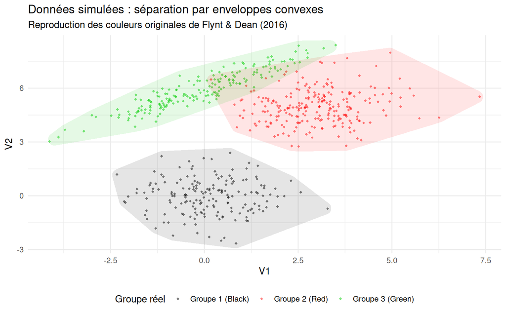

Figure 1: Représentation par enveloppes convexes avec les couleurs de l’article original (Noir, Rouge, Vert).

```r
set.seed(288)

pi_vec <- c(0.3, 0.4, 0.3)
mu <- list(c(0, 0), c(3, 5), c(0, 6))

sigma_sph <- diag(2)
sigma_ell <- matrix(c(2, 1.3, 1.3, 1), nrow = 2, byrow = TRUE)

cl_real <- sample(1:3, size = 600, replace = TRUE, prob = pi_vec)

X_data <- purrr::map_dfr(cl_real, function(i) {
  sigma_i <- if (i == 3L) sigma_ell else sigma_sph
  rmvnorm(n = 1, mean = mu[[i]], sigma = sigma_i) |> as_tibble()
}) |>
  set_names(c("V1", "V2"))

X_plot <- X_data |>
  mutate(Groupe = as.factor(cl_real)) |>
  filter(!is.na(V1) & !is.na(V2))

couleurs_article <- c("1" = "black", "2" = "red", "3" = "green3")

ggplot(X_plot, aes(x = V1, y = V2, color = Groupe)) +
  geom_point(alpha = 0.5, size = 1.2, shape = 18) +
  ggforce::geom_mark_hull(
    aes(fill = Groupe), alpha = 0.10, color = NA,
    concavity = 10000, na.rm = TRUE, expand = unit(2, "mm")
  ) +
  scale_color_manual(values = couleurs_article, name = "Groupe réel",
                     labels = c("Groupe 1 (Black)", "Groupe 2 (Red)", "Groupe 3 (Green)")) +
  scale_fill_manual(values = couleurs_article) +
  labs(title    = "Données simulées : séparation par enveloppes convexes",
       subtitle = "Reproduction des couleurs originales de Flynt & Dean (2016)",
       x = "V1", y = "V2") +
  theme_minimal() +
  theme(legend.position = "bottom") +
  guides(fill = "none")
```

**AvertissementPoint d’attention**

Le Groupe 3 (en haut) forme une ellipse inclinée. Le K-means, qui suppose des clusters sphériques, aura du mal à le détecter correctement. Mclust, qui modélise explicitement les ellipses, le capturera bien.

## 3.4 Méthodes de partitionnement géométrique

### 3.4.1 K-means : la méthode des barycentres

#### Principe et intuition

Le K-means est l’algorithme de clustering le plus célèbre et le plus utilisé au monde (MacQueen 1967; Lloyd 1982). Son principe :

> *Chaque individu appartient au groupe dont le centre (la moyenne) lui est le plus proche.*

**NoteAnalogie pédagogique**

Imaginez 3 personnes dans une salle bondée, chacune criant : “Venez vers moi !” Chaque individu rejoint la plus proche. Puis chaque personne se déplace au centre géographique de son groupe. On recommence jusqu’à stabilisation. C’est exactement l’algorithme K-means.

#### Formalisation mathématique

K-means minimise la *somme des distances au carré intra-cluster* (WSS, *Within-Cluster Sum of Squares*) :

```latex
$$\mathrm{WSS} = \sum_{k=1}^{K} \sum_{\boldsymbol{x}_{i} \in C_{k}} \lVert \boldsymbol{x}_{i} - \boldsymbol{\mu}_{k} \rVert^{2}$$
```

$$\mathrm{WSS} = \sum_{k=1}^{K} \sum_{\boldsymbol{x}_{i} \in C_{k}} \lVert \boldsymbol{x}_{i} - \boldsymbol{\mu}_{k} \rVert^{2}$$

L’algorithme procède en quatre étapes itératives :

1. **Initialisation** : placer $K$ centroïdes au hasard dans l’espace des données.
2. **Attribution** : affecter chaque observation au centroïde le plus proche — $d(\boldsymbol{x}, \boldsymbol{\mu}_k) = \lVert \boldsymbol{x} - \boldsymbol{\mu}_k \rVert$.
3. **Mise à jour** : recalculer chaque centroïde comme la moyenne arithmétique de son groupe.
4. **Convergence** : répéter les étapes 2–3 jusqu’à ce qu’aucune observation ne change de groupe.

La figure ci-dessous, extraite de Lebart, Morineau, et Piron (1995), illustre graphiquement ces quatre étapes pour $K = 2$ groupes. On y observe, de haut en bas : le tirage aléatoire des deux centres initiaux ($C_1^0$ et $C_2^0$) ; la constitution des deux premières classes ($I_1^0$ et $I_2^0$) délimitées par la frontière médiane perpendiculaire au segment joignant les deux centres ; le déplacement des barycentres ($C_1^1$, $C_2^1$) vers le centre de masse de chaque classe ; puis la convergence vers une partition finale stable ($I_1^2$, $I_2^2$). La frontière de séparation (trait oblique) se déplace à chaque itération jusqu’à ce que les classes ne changent plus.

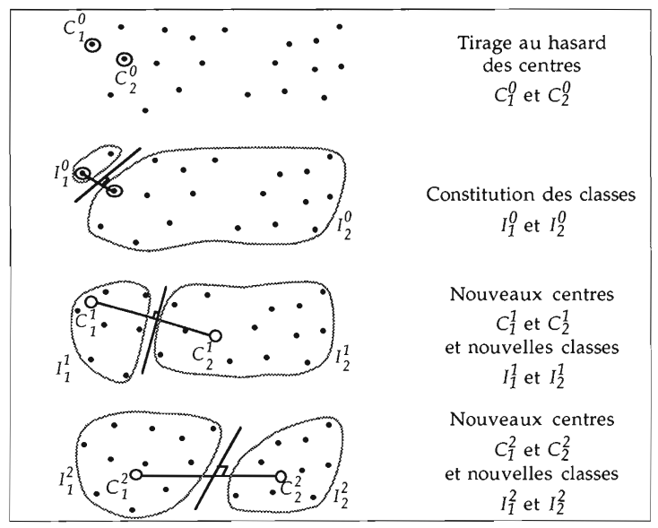

Figure 2: Illustration de l’algorithme K-means ($K = 2$) en quatre étapes successives : initialisation aléatoire des centres ($C_1^0$, $C_2^0$), formation des classes ($I_1^0$, $I_2^0$), recalcul des barycentres et convergence vers la partition finale. *Source : Lebart, Morineau, et Piron (1995).*

#### Choisir K : la méthode du coude

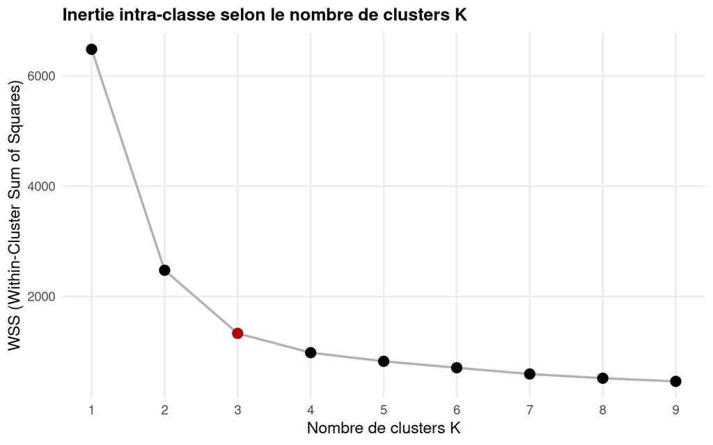

Figure 3: Méthode du coude. Le point rouge (K = 3) marque l’inflexion de la courbe : au-delà, ajouter un cluster n’apporte que peu de gain en inertie.

```r
elbow_data <- tibble(k = 1:9) |>
  mutate(
    model = purrr::map(k, ~ kmeans(X_data, centers = .x, nstart = 50)),
    wss   = purrr::map_dbl(model, ~ .x$tot.withinss)
  )

ggplot(elbow_data, aes(x = k, y = wss)) +
  geom_line(color = "gray70", linewidth = 0.9) +
  geom_point(aes(color = (k == 3)), size = 3.5) +
  scale_color_manual(values = c("black", "#B40000")) +
  scale_x_continuous(breaks = 1:9) +
  labs(title = "Inertie intra-classe selon le nombre de clusters K",
       x     = "Nombre de clusters K",
       y     = "WSS (Within-Cluster Sum of Squares)") +
  guides(color = "none")
```

**AvertissementLimites du K-means**

1. il suppose des clusters sphériques, inadapté aux formes elliptiques ; (2) il est sensible aux valeurs aberrantes ; (3) il n’exprime aucune incertitude : chaque individu est assigné définitivement à un seul groupe ; (4) il ne fonctionne que sur des variables continues.

#### Six variations pour générer la courbe WSS

*Variation 1 — Méthode manuelle*

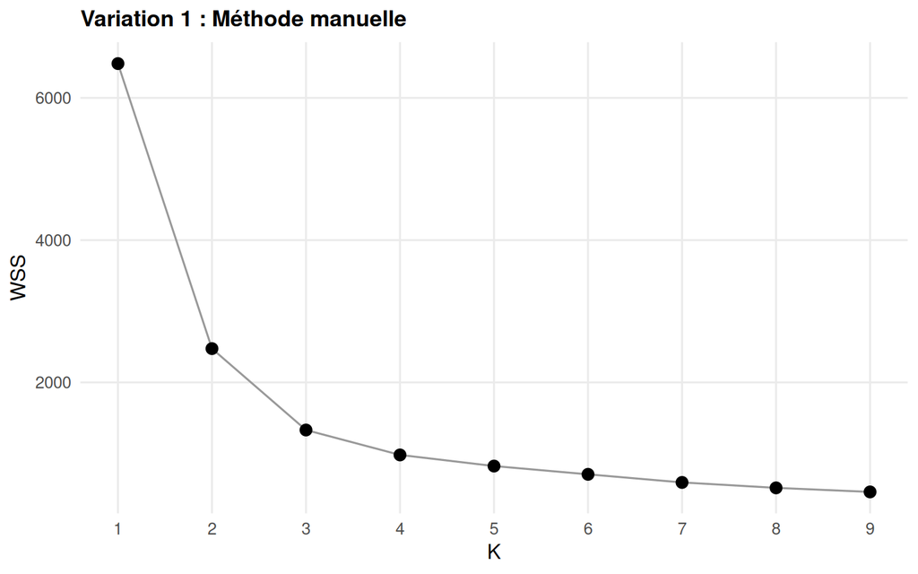

```r
km1 <- kmeans(X_data, 1, nstart = 50); km2 <- kmeans(X_data, 2, nstart = 50)
km3 <- kmeans(X_data, 3, nstart = 50); km4 <- kmeans(X_data, 4, nstart = 50)
km5 <- kmeans(X_data, 5, nstart = 50); km6 <- kmeans(X_data, 6, nstart = 50)
km7 <- kmeans(X_data, 7, nstart = 50); km8 <- kmeans(X_data, 8, nstart = 50)
km9 <- kmeans(X_data, 9, nstart = 50)

wss_man <- c(km1$tot.withinss, km2$tot.withinss, km3$tot.withinss,
             km4$tot.withinss, km5$tot.withinss, km6$tot.withinss,
             km7$tot.withinss, km8$tot.withinss, km9$tot.withinss)

ggplot(tibble(k = 1:9, wss = wss_man), aes(k, wss)) +
  geom_line(color = "gray60") + geom_point(size = 3) +
  scale_x_continuous(breaks = 1:9) +
  labs(title = "Variation 1 : Méthode manuelle", x = "K", y = "WSS")
```

*Variation 2 — Boucle for*

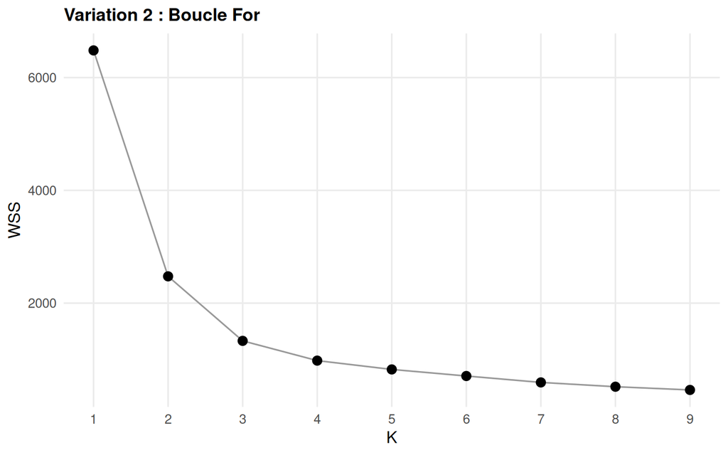

```r
wss_for <- numeric(9)
for (i in 1:9) {
  wss_for[i] <- kmeans(X_data, centers = i, nstart = 50)$tot.withinss
}

ggplot(tibble(k = 1:9, wss = wss_for), aes(k, wss)) +
  geom_line(color = "gray60") + geom_point(size = 3) +
  scale_x_continuous(breaks = 1:9) +
  labs(title = "Variation 2 : Boucle For", x = "K", y = "WSS")
```

*Variation 3 — sapply*

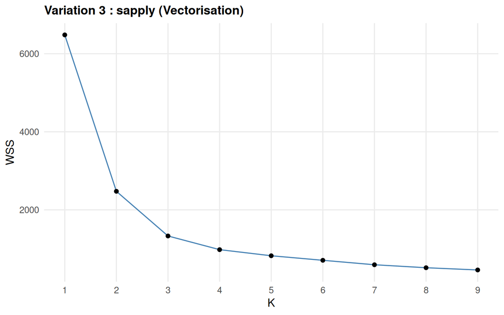

```r
wss_sapply <- sapply(1:9, function(k) {
  kmeans(X_data, centers = k, nstart = 50)$tot.withinss
})

ggplot(tibble(k = 1:9, wss = wss_sapply), aes(k, wss)) +
  geom_line(color = "steelblue") + geom_point() +
  scale_x_continuous(breaks = 1:9) +
  labs(title = "Variation 3 : sapply (Vectorisation)", x = "K", y = "WSS")
```

*Variation 4 — purrr*

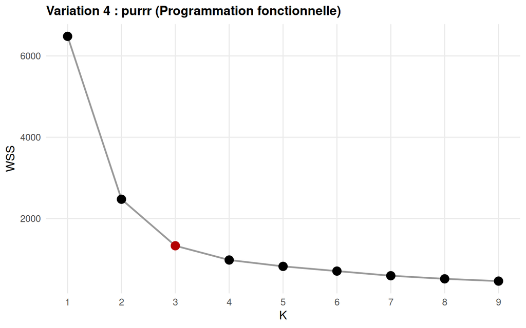

```r
elbow_purrr <- tibble(k = 1:9) |>
  mutate(
    model = purrr::map(k, ~ kmeans(X_data, centers = .x, nstart = 50)),
    wss   = purrr::map_dbl(model, ~ .x$tot.withinss)
  )

ggplot(elbow_purrr, aes(k, wss)) +
  geom_line(linewidth = 0.9, color = "gray60") +
  geom_point(aes(color = (k == 3)), size = 4) +
  scale_color_manual(values = c("black", "#B40000"), guide = "none") +
  scale_x_continuous(breaks = 1:9) +
  labs(title = "Variation 4 : purrr (Programmation fonctionnelle)", x = "K", y = "WSS")
```

*Variation 5 — broom*

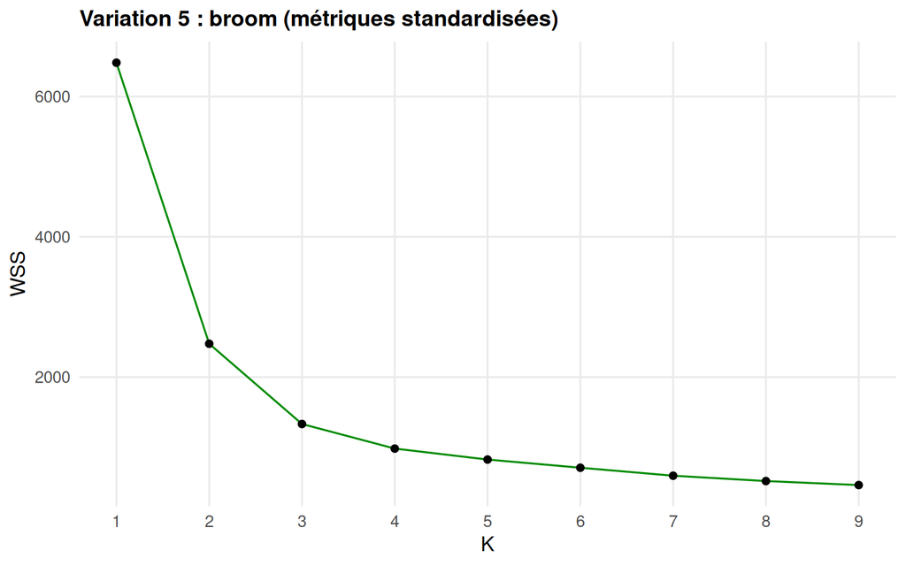

```r
elbow_broom <- tibble(k = 1:9) |>
  mutate(
    model = purrr::map(k, ~ kmeans(X_data, centers = .x, nstart = 50)),
    stats = purrr::map(model, broom::glance)
  ) |>
  tidyr::unnest(stats)

ggplot(elbow_broom, aes(k, tot.withinss)) +
  geom_line(color = "green4") + geom_point() +
  scale_x_continuous(breaks = 1:9) +
  labs(title = "Variation 5 : broom (métriques standardisées)", y = "WSS", x = "K")
```

*Variation 6 — factoextra (clé en main)*

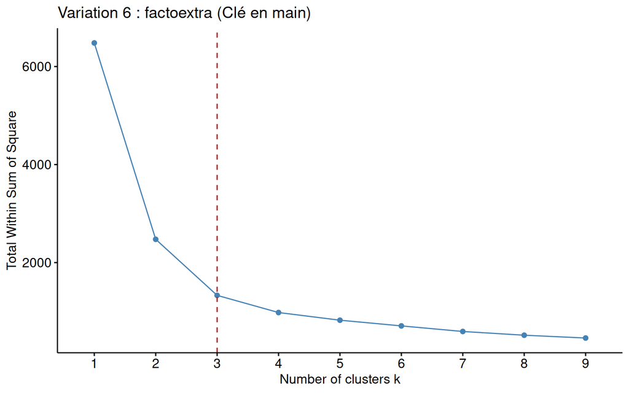

```r
fviz_nbclust(X_data, kmeans, method = "wss", k.max = 9, nstart = 50) +
  geom_vline(xintercept = 3, linetype = 2, color = "firebrick") +
  labs(title = "Variation 6 : factoextra (Clé en main)")
```

**AstuceÀ retenir**

Les six courbes WSS produites sont *statistiquement identiques* : toutes indiquent un coude en $k = 3$, confirmant exactement la structure simulée par Flynt & Dean. Le choix de la variation est donc un choix de *style de code* et de contexte d’usage.

```r
data.frame(
  Methode   = c("Manuelle", "Boucle For", "sapply", "purrr", "broom", "factoextra"),
  Avantage  = c("Transparence totale", "Logique universelle", "Concis (Base R)",
                "Traçabilité complète", "Métriques multiples", "Rapidité, esthétique"),
  Inconvenient = c("Très verbeux", "Plus de lignes", "Modèle perdu",
                   "Syntaxe complexe", "Package sup.", "\"Boîte noire\""),
  Usage     = c("Apprentissage", "Débutants", "Scripts légers",
                "Pipelines DS", "Rapports stats", "Exploration")
) |>
  kable(
    caption   = "Tableau de synthèse des six variations d'implémentation de la méthode du coude.",
    col.names = c("Méthode", "Avantage principal", "Inconvénient", "Usage idéal")
  ) |>
  kable_styling(bootstrap_options = c("striped", "hover"), full_width = FALSE)
```

Tableau 3: Tableau de synthèse des six variations d'implémentation de la méthode du coude.

| Méthode | Avantage principal | Inconvénient | Usage idéal |
| --- | --- | --- | --- |
| Manuelle | Transparence totale | Très verbeux | Apprentissage |
| Boucle For | Logique universelle | Plus de lignes | Débutants |
| sapply | Concis (Base R) | Modèle perdu | Scripts légers |
| purrr | Traçabilité complète | Syntaxe complexe | Pipelines DS |
| broom | Métriques multiples | Package sup. | Rapports stats |
| factoextra | Rapidité, esthétique | "Boîte noire" | Exploration |

### 3.4.2 Superposition K-means / vérité terrain

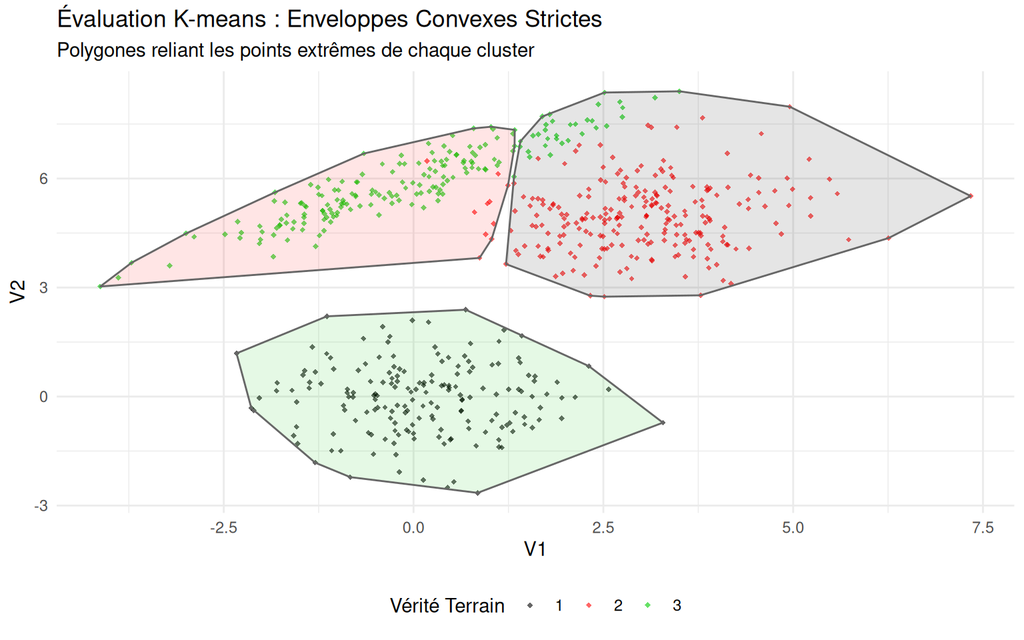

Figure 4: Évaluation visuelle du K-means avec enveloppes convexes strictes (définition mathématique par segments reliant les points extrêmes).

```r
set.seed(123)
km_res <- kmeans(X_data, centers = 3, nstart = 25)

X_eval <- X_data |>
  mutate(
    Vrai_Groupe = as.factor(cl_real),
    Cluster_KM  = as.factor(km_res$cluster)
  )

ggplot(X_eval, aes(x = V1, y = V2)) +
  geom_point(aes(color = Vrai_Groupe), alpha = 0.6, size = 1.2, shape = 18) +
  ggforce::geom_mark_hull(
    aes(fill = Cluster_KM, group = Cluster_KM),
    alpha = 0.10, color = "gray40", linetype = "solid",
    concavity = 10000, radius = unit(0, "mm"),
    expand = unit(0, "mm"), na.rm = TRUE
  ) +
  scale_color_manual(values = couleurs_article, name = "Vérité Terrain") +
  scale_fill_manual(values = couleurs_article) +
  labs(title    = "Évaluation K-means : Enveloppes Convexes Strictes",
       subtitle = "Polygones reliant les points extrêmes de chaque cluster",
       x = "V1", y = "V2") +
  theme_minimal() +
  theme(legend.position = "bottom") +
  guides(fill = "none")
```

```r
km3     <- kmeans(X_data, 3, nstart = 50)
tab_km  <- table(cl_real, km3$cluster)
cat("Table de contingence K-means vs vérité terrain :\n")
```

```
#> Table de contingence K-means vs vérité terrain :
```

```r
print(tab_km)
```

```
#>
#> cl_real   1   2   3
#>       1   0   0 177
#>       2 227  10   0
#>       3  33 153   0
```

```r
reussite_points <- sum(apply(tab_km, 1, max))
total_points    <- sum(tab_km)
taux_reussite   <- (reussite_points / total_points) * 100
taux_erreur     <- 100 - taux_reussite

cat("\nTaux de réussite :", round(taux_reussite, 2), "%")
```

```
#>
#> Taux de réussite : 92.83 %
```

```r
cat("\nTaux d'erreur    :", round(taux_erreur, 2), "%")
```

```
#>
#> Taux d'erreur    : 7.17 %
```

```r
data.frame(
  Indicateur = c("Points bien classés", "Taux de réussite", "Taux d'erreur"),
  Resultat   = c(paste0(reussite_points, " / ", total_points),
                 paste0(round(taux_reussite, 2), " %"),
                 paste0(round(taux_erreur, 2), " %"))
) |>
  kable(
    col.names = c("Indicateur de performance", "Résultat"),
    caption   = "Analyse de la précision du K-means (K=3) sur les données Flynt & Dean."
  ) |>
  kable_styling(bootstrap_options = c("striped", "hover"), full_width = FALSE)
```

Tableau 4: Analyse de la précision du K-means (K=3) sur les données Flynt & Dean.

| Indicateur de performance | Résultat |
| --- | --- |
| Points bien classés | 557 / 600 |
| Taux de réussite | 92.83 % |
| Taux d'erreur | 7.17 % |

**AvertissementEn conclusion**

Si le Groupe 1 valide l’efficacité de l’approche dans des conditions simples, les Groupes 2 et 3 démontrent que la propreté visuelle d’un clustering ne garantit pas sa justesse statistique. Le K-means impose sa propre géométrie (sphérique) aux données au lieu de s’adapter à la leur (elliptique).

### 3.4.3 Classification hiérarchique ascendante (CHA)

#### Principe

La *classification hiérarchique ascendante* (CHA) construit un *dendrogramme* — un arbre de fusion représentant quels individus ou groupes ont été réunis, et à quelle distance (Everitt et al. 2011). Elle ne requiert pas de spécifier $K$ à l’avance.

La liaison moyenne (UPGMA) définit la distance entre deux groupes $A$ et $B$ comme la moyenne de toutes les distances inter-individuelles :

```latex
$$d(A, B) = \frac{1}{|A| \cdot |B|} \sum_{i \in A} \sum_{j \in B} d(x_i, x_j)$$
```

$$d(A, B) = \frac{1}{|A| \cdot |B|} \sum_{i \in A} \sum_{j \in B} d(x_i, x_j)$$

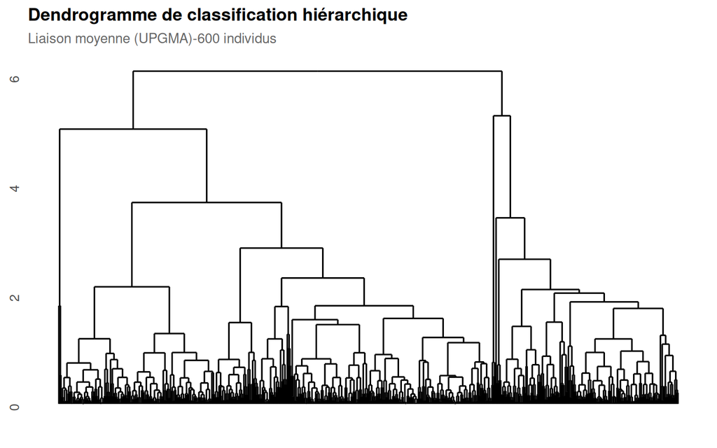

Figure 5: Dendrogramme de classification hiérarchique (liaison moyenne, 600 individus). La hauteur d’une jonction représente la distance de fusion. Pour K = 3, on coupe au niveau de la 3e plus grande fusion.

```r
d_mat   <- dist(X_data, method = "euclidean")
h_avg   <- hclust(d_mat, method = "average")

ggdendrogram(h_avg, rotate = FALSE, size = 0.15) +
  labs(
    title    = "Dendrogramme de classification hiérarchique",
    subtitle = "Liaison moyenne (UPGMA)-600 individus"
  ) +
  theme(axis.text.x  = element_blank(),
        axis.ticks.x = element_blank())
```

#### La méthode hiérarchique CAH sur les données simulées

Dans l’article de Flynt & Dean (2016), la méthode du lien moyen peut s’avérer encore moins performante que le K-means sur ces structures, entraînant un taux d’erreur avoisinant les 30 %. La raison fondamentale : la CAH fusionne des sous-groupes de façon *irréversible* (*greedy*), sans pouvoir réassigner un point mal placé.

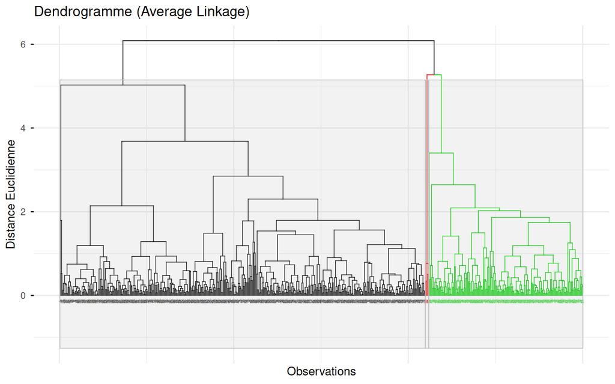

Figure 6: Dendrogramme (lien moyen, 600 individus) avec découpage en 3 clusters selon les couleurs de l’article.

```r
res.hc <- hclust(dist(X_data), method = "average")

fviz_dend(res.hc,
          k          = 3,
          cex        = 0.15,
          lwd        = 0.30,
          rect       = TRUE,
          rect_fill  = TRUE,
          rect_lty   = 1,
          palette    = c("black", "red", "green3"),
          main       = "Dendrogramme (Average Linkage)",
          xlab       = "Observations",
          ylab       = "Distance Euclidienne",
          ggtheme    = theme_minimal()) +
  scale_linewidth(range = c(0.30, 0.30)) +
  theme(
    axis.text.x     = element_blank(),
    legend.position = "none"
  )
```

#### La version circulaire

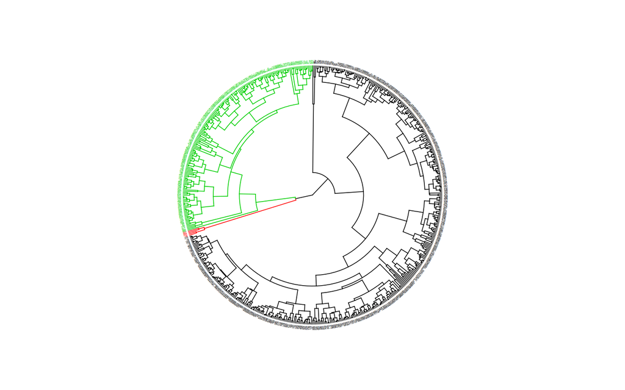

Figure 7: Dendrogramme circulaire (lien moyen, 600 individus) avec découpage en 3 clusters.

```r
library(patchwork)
library(grid)

# 1. Construction du plot
p_circ <- fviz_dend(res.hc,
                    k           = 3,
                    type        = "circular",
                    cex         = 0.15,
                    rect        = TRUE,
                    rect_fill   = TRUE,
                    palette     = c("black", "red", "green3"),
                    main        = "Dendrogramme Circulaire (Average Linkage)",
                    ggtheme     = theme_void())

# 2. Patch linewidth sur tous les segments
for (i in seq_along(p_circ$layers)) {
  geom_class <- class(p_circ$layers[[i]]$geom)
  if (any(geom_class %in% c("GeomSegment", "GeomCurve", "GeomPath"))) {
    p_circ$layers[[i]]$aes_params$linewidth <- 0.30
    p_circ$layers[[i]]$aes_params$size      <- 0.30
  }
}

p_circ <- p_circ +
  scale_linewidth(range = c(0.30, 0.30)) +
  theme_void() +
  theme(legend.position = "none")

# 3. Suppression des labels radiaux
gb <- ggplot_build(p_circ)
gb$layout$panel_params[[1]]$r.labels <- character(0)
gb$layout$panel_params[[1]]$r.major  <- numeric(0)
gb$layout$panel_params[[1]]$r.minor  <- numeric(0)
gt <- ggplot_gtable(gb)

# 4. Rendu compatible Quarto
wrap_elements(gt)
```

#### Le calcul (30 % d’erreur)

Pour retrouver les chiffres de l’article, il faut regarder si les points de *différentes couleurs* sont mélangés dans le même cluster :

```r
hRed  <- hclust(dist(X_data[1:2]), method = "average")
H2cut <- cutree(hRed, k = 3)
table(cl_real, H2cut)
```

```
#>        H2cut
#> cl_real   1   2   3
#>       1   0 177   0
#>       2 237   0   0
#>       3 182   0   4
```

Taux de réussite : $(237+177+4)/600 = 69{,}7\,\%$ — Taux d’erreur : $182/600 = 30{,}3\,\%$

**AvertissementConstat de Flynt & Dean**

**AstuceÀ retenir**

La méthode hiérarchique est utile pour explorer la structure des données, mais pour un partitionnement robuste sur ces données simulées, le K-means (et a fortiori Mclust) reste largement supérieur.

## 3.5 Méthodes basées sur les modèles probabilistes

**NoteAnalogie : du déterministe au probabiliste**

Le K-means affecte chaque observation à *un seul* groupe de façon déterministe : “Tu appartiens au groupe 2, point final.” Le GMM est plus nuancé : “Tu appartiens au groupe 2 avec une probabilité de 78 %, au groupe 1 avec 18 %, au groupe 3 avec 4 %.” Cette *appartenance probabiliste* est à la fois plus réaliste et plus informative.

### 3.5.1 Le modèle de mélange gaussien (GMM)

`mclust` ajuste un *modèle de mélange gaussien* (GMM) : on suppose que la population est composée de $K$ sous-populations gaussiennes, chacune caractérisée par un poids $\pi_k$, un centre $\boldsymbol{\mu}_k$ et une dispersion $\boldsymbol{\Sigma}_k$. La densité de mélange s’écrit :

$$f(x_i) = \sum_{k=1}^{K} \pi_k \,
\mathcal{N}_p(x_i \mid \boldsymbol{\mu}_k, \boldsymbol{\Sigma}_k)$$

avec $\sum_{k=1}^K \pi_k = 1$ et $\pi_k > 0$.

### 3.5.2 L’algorithme EM

Les paramètres $\Theta = \{\pi_k, \boldsymbol{\mu}_k, \boldsymbol{\Sigma}_k\}_{k=1}^K$ sont estimés par maximum de vraisemblance via l’algorithme *EM* (Expectation-Maximisation) (Dempster, Laird, et Rubin 1977), qui alterne deux étapes jusqu’à convergence.

*Étape E (Expectation)* — calcul des responsabilités $r_{ik}$ :

$$r_{ik} = \frac{\pi_k \cdot \mathcal{N}_p(x_i\mid\boldsymbol{\mu}_k, \boldsymbol{\Sigma}_k)}
{\displaystyle\sum_{j=1}^{K} \pi_j \cdot
\mathcal{N}_p(x_i\mid\boldsymbol{\mu}_j, \boldsymbol{\Sigma}_j)}$$

$r_{ik} \in [0,1]$ est la probabilité *a posteriori* que l’observation $x_i$ provienne de la composante $k$ (application directe de la règle de Bayes). On a $\sum_k r_{ik} = 1$ pour tout $i$ : là où le K-means donne une appartenance dure (0 ou 1), le GMM produit un vecteur complet de probabilités (*soft assignment*).

*Étape M (Maximisation)* — mise à jour des paramètres à partir des effectifs pondérés $n_k = \sum_i r_{ik}$ :

$$\hat{\pi}_k = \frac{n_k}{n}, \qquad
\hat{\boldsymbol{\mu}}_k = \frac{1}{n_k}\sum_i r_{ik}\, x_i, \qquad
\hat{\boldsymbol{\Sigma}}_k = \frac{1}{n_k}\sum_i
r_{ik}(x_i - \hat{\boldsymbol{\mu}}_k)(x_i - \hat{\boldsymbol{\mu}}_k)^\top$$

**AstuceÀ retenir**

La log-vraisemblance $\ell(\Theta) = \sum_i \ln f(x_i)$ est *garantie non décroissante* à chaque itération EM. L’algorithme s’arrête quand l’incrément $|\ell^{(t+1)} - \ell^{(t)}| < \varepsilon$ (défaut : $10^{-5}$ dans `mclust`). En pratique, on relance depuis plusieurs initialisations pour éviter les maxima locaux.

### 3.5.3 Les 14 familles de modèles de covariance

La richesse de `mclust` tient à sa paramétrisation par décomposition propre de $\boldsymbol{\Sigma}_k$ :

$$\boldsymbol{\Sigma}_k = \lambda_k \, D_k \, A_k \, D_k^\top$$

$\lambda_k$ contrôle le *volume*, $D_k$ l’*orientation*, $A_k$ la *forme* ($\det A_k = 1$). En contraignant (E = Égal entre groupes) ou libérant (V = Variable) chacune de ces trois composantes, `mclust` définit 14 familles de modèles (EII, VII, EEI, EEE, …, VVV).

### 3.5.4 La vraisemblance : mesurer l’adéquation du modèle

La *log-vraisemblance* $\ell(\Theta)$ mesure à quel point le modèle ajusté “colle” aux données observées :

$$\ell(\Theta) = \sum_{i=1}^{n} \ln\!\left[
\sum_{k=1}^{K} \pi_k \, \mathcal{N}_p(x_i \mid \boldsymbol{\mu}_k, \boldsymbol{\Sigma}_k)
\right]$$

**NoteIntuition de la vraisemblance**

Imaginez 600 élèves répartis dans 3 classes. La vraisemblance répond à : *“Quelle configuration de classes (centres, dispersions, proportions) aurait le plus de chances de produire exactement ces 600 élèves ?”* Plus $\ell$ est grand (moins négatif), mieux le modèle explique les données. L’algorithme EM cherche les paramètres qui maximisent $\ell$.

Chaque terme $\ln[\ldots]$ est négatif (log d’une probabilité $< 1$), donc $\ell < 0$ en général. Un modèle avec plus de composantes $K$ ou plus de paramètres libres atteint toujours une vraisemblance au moins aussi élevée — d’où la nécessité de la pénalisation du BIC.

### 3.5.5 Les degrés de liberté : le coût de la complexité

Le paramètre $d$ dans la formule du BIC est le *nombre de paramètres libres* du modèle. Pour les données de Flynt & Dean ($p = 2$ variables, $K = 3$ groupes) :

| Composante | Formule | Valeur |
| --- | --- | --- |
| Proportions $\pi_k$ | $K - 1$ | 2 |
| Moyennes $\boldsymbol{\mu}_k$ | $K \times p$ | 6 |
| Covariances (selon modèle) | variable | dépend de la famille |

Un modèle VVV (totalement libre) utilise $p(p+1)/2 = 3$ paramètres par matrice de covariance, soit $3 \times 3 = 9$ supplémentaires, pour un total de $d = 17$. Des familles plus contraintes (EEE, EVE…) partagent des paramètres entre groupes et comptent moins de degrés de liberté.

**AstuceÀ retenir**

Le modèle sélectionné par `mclust` expose son $d$ via `mc_model_v2$df` en R. Sur $n = 600$ observations, $\ln(600) \approx 6{,}4$ : chaque paramètre supplémentaire coûte environ *6,4 points de BIC*, ce qui rend la pénalisation très efficace pour écarter les modèles sur-paramétrés.

### 3.5.6 Sélection automatique via le BIC

`mclust` (Fraley et Raftery 2002; Scrucca et al. 2016) sélectionne simultanément $K$ et la famille de covariance en maximisant le BIC de Fraley-Raftery (Schwarz 1978) :

$$\text{BIC} = \underbrace{2\ln\hat{L}}_{\text{ajustement}} -
\underbrace{d\ln n}_{\text{pénalité complexité}}$$

**Avertissement**

*Convention inversée.* Dans la littérature standard, le BIC se *minimise* ($-2\ln\hat{L} + d\ln n$). Dans `mclust`, il se *maximise* — signe opposé, même principe de pénalisation de la complexité. Ne pas confondre les deux conventions en comparant des sources différentes.

```r
mc_model_v2 <- Mclust(X_data[, 1:2])
tab_mc_v2   <- table(Vérité = cl_real, Mclust = mc_model_v2$classification)

cat("=== Modele optimal selectionne par mclust ===\n")
```

```
#> === Modele optimal selectionne par mclust ===
```

```r
cat("Modele de covariance :", mc_model_v2$modelName, "\n")
```

```
#> Modele de covariance : VVE
```

```r
cat("Nombre de composantes K :", mc_model_v2$G, "\n")
```

```
#> Nombre de composantes K : 3
```

```r
cat("Degres de liberte (d) :", mc_model_v2$df, "\n")
```

```
#> Degres de liberte (d) : 15
```

```r
cat("Log-vraisemblance (l) :", round(mc_model_v2$loglik, 2), "\n")
```

```
#> Log-vraisemblance (l) : -2230.69
```

```r
cat("BIC Fraley-Raftery    :", round(mc_model_v2$bic, 2), "\n")
```

```
#> BIC Fraley-Raftery    : -4557.34
```

```r
reussite_mc      <- sum(apply(tab_mc_v2, 1, max))
taux_reussite_mc <- (reussite_mc / nrow(X_data)) * 100
taux_erreur_mc   <- 100 - taux_reussite_mc
```

```r
bic_matrix <- mc_model_v2$BIC
bic_df <- data.frame(
  K      = as.integer(rep(row.names(bic_matrix), ncol(bic_matrix))),
  Modele = rep(colnames(bic_matrix), each = nrow(bic_matrix)),
  BIC    = round(as.vector(bic_matrix), 2)
)
bic_df <- bic_df[!is.na(bic_df$BIC), ]
bic_df <- bic_df[order(-bic_df$BIC), ]
bic_top5 <- head(bic_df, 5)
row.names(bic_top5) <- NULL

kable(bic_top5,
      col.names = c("K", "Modèle", "BIC"),
      caption   = "Cinq meilleurs modèles selon le BIC de Fraley-Raftery (plus élevé = meilleur).") |>
  kable_styling(bootstrap_options = c("striped", "hover"), full_width = FALSE) |>
  row_spec(1, bold = TRUE, color = "white", background = "#003A70")
```

Tableau 5: Cinq meilleurs modèles selon le BIC de Fraley-Raftery (plus élevé = meilleur).

| K | Modèle | BIC |
| --- | --- | --- |
| 3 | VVE | -4557.34 |
| 3 | EVE | -4565.03 |
| 3 | VVV | -4566.27 |
| 3 | EVV | -4571.73 |
| 4 | VVE | -4581.89 |

```r
data.frame(
  Indicateur = c("Points bien capturés", "Taux de réussite (Capture)", "Taux d'erreur"),
  Resultat   = c(paste0(reussite_mc, " / ", nrow(X_data)),
                 paste0(round(taux_reussite_mc, 2), " %"),
                 paste0(round(taux_erreur_mc, 2), " %"))
) |>
  kable(
    col.names = c("Indicateur", "Résultat"),
    caption   = "Performance du modèle Mclust (G=3) sur les données Flynt & Dean."
  ) |>
  kable_styling(bootstrap_options = c("striped", "hover"), full_width = FALSE) |>
  row_spec(2, bold = TRUE, color = "white", background = "#28a745")
```

Tableau 6: Performance du modèle Mclust (G=3) sur les données Flynt & Dean.

| Indicateur | Résultat |
| --- | --- |
| Points bien capturés | 592 / 600 |
| Taux de réussite (Capture) | 98.67 % |
| Taux d'erreur | 1.33 % |

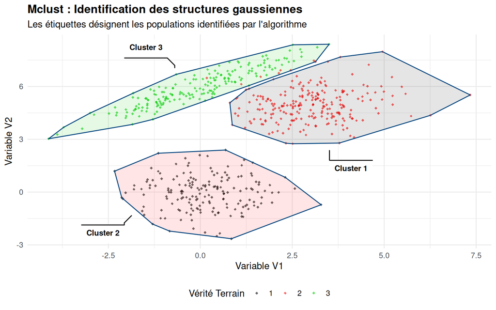

Figure 8: Mclust (G=3) : enveloppes convexes étiquetées. Les contours épousent la forme elliptique du Groupe 3, contrairement aux enveloppes du K-means.

```r
mc_res_v2 <- Mclust(X_data[, 1:2], G = 3)

X_mclust_v2 <- X_data |>
  mutate(
    Verite         = as.factor(cl_real),
    Cluster_Mclust = as.factor(mc_res_v2$classification)
  )

bleu_v2 <- rgb(0, 70, 127, maxColorValue = 255)

ggplot(X_mclust_v2, aes(x = V1, y = V2)) +
  geom_point(aes(color = Verite), alpha = 0.6, size = 1.2, shape = 18) +
  ggforce::geom_mark_hull(
    aes(fill = Cluster_Mclust, group = Cluster_Mclust,
        label = paste("Cluster", Cluster_Mclust)),
    alpha = 0.10, color = bleu_v2, linetype = "solid",
    concavity = 10000, radius = unit(0, "mm"), expand = unit(0, "mm"),
    label.buffer = unit(5, "mm"), label.fontsize = 9,
    label.fontface = "bold", na.rm = TRUE
  ) +
  scale_color_manual(values = couleurs_article, name = "Vérité Terrain") +
  scale_fill_manual(values = couleurs_article) +
  labs(title    = "Mclust : Identification des structures gaussiennes",
       subtitle = "Les étiquettes désignent les populations identifiées par l'algorithme",
       x = "Variable V1", y = "Variable V2") +
  theme_minimal() +
  theme(legend.position = "bottom", plot.title = element_text(face = "bold")) +
  guides(fill = "none")
```

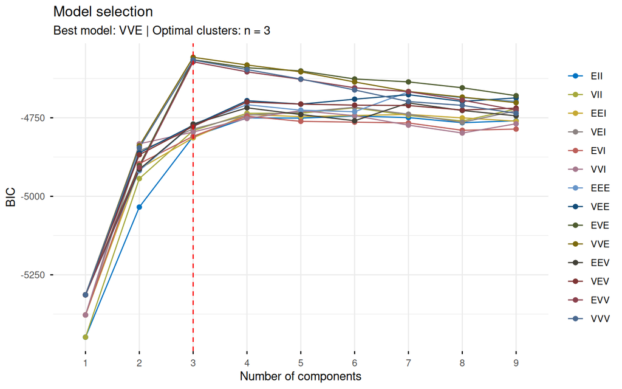

Figure 9: Sélection du modèle optimal par critère BIC (visualisation factoextra). Le meilleur modèle est clairement identifié pour K=3.

```r
mc_full_fviz <- Mclust(X_data[, 1:2], G = 1:9)
fviz_mclust_bic(mc_full_fviz, palette = "jco", legend = "right",
                ggtheme = theme_minimal())
```

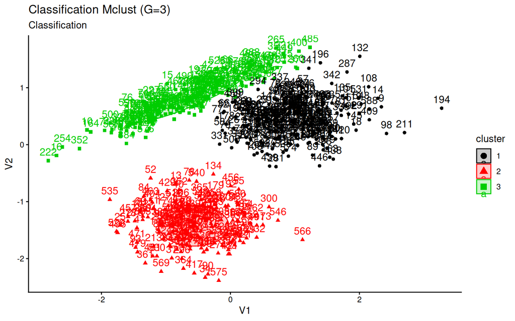

Figure 10: Classification Mclust (G=3) : chaque individu est coloré selon son groupe d’appartenance identifié par l’algorithme.

```r
fviz_mclust(mc_res_v2, what = "classification",
            palette = c("black", "red", "green3"),
            ggtheme = theme_minimal(),
            main    = "Classification Mclust (G=3)")
```

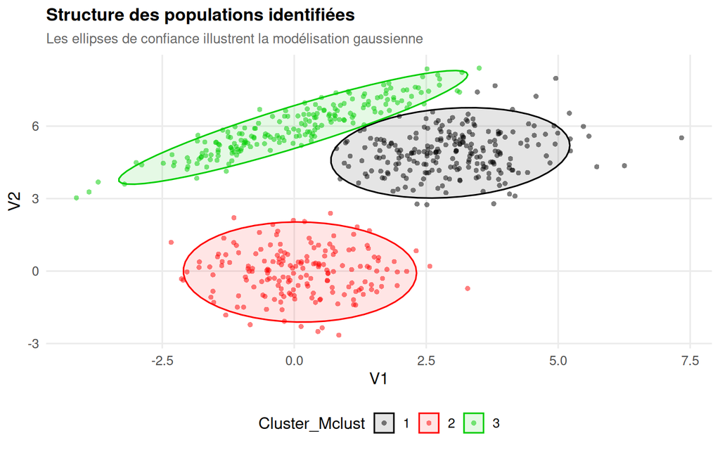

Figure 11: Structure des populations identifiées par Mclust avec ellipses de confiance à 95%.

```r
ggplot(X_mclust_v2, aes(x = V1, y = V2, color = Cluster_Mclust)) +
  geom_point(alpha = 0.5, size = 1.5, shape = 16) +
  stat_ellipse(aes(fill = Cluster_Mclust), geom = "polygon", alpha = 0.1, level = 0.95) +
  scale_color_manual(values = c("black", "red", "green3")) +
  scale_fill_manual(values  = c("black", "red", "green3")) +
  labs(title    = "Structure des populations identifiées",
       subtitle = "Les ellipses de confiance illustrent la modélisation gaussienne")
```

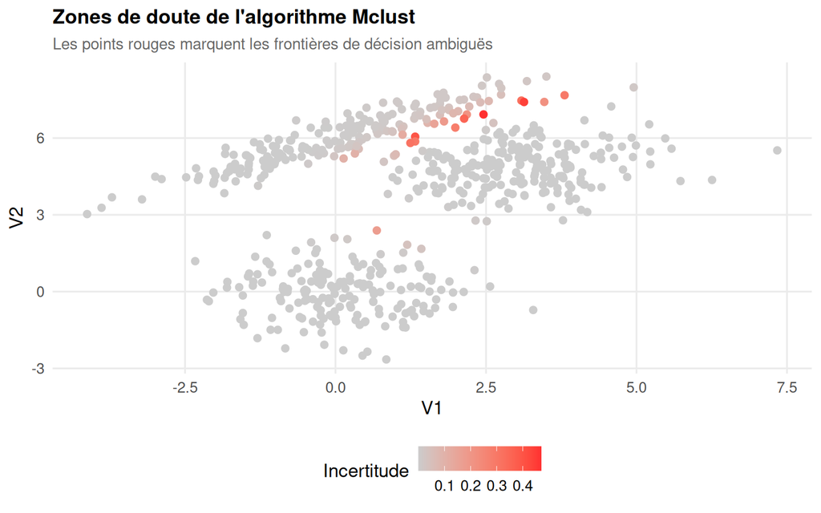

Figure 12: Cartographie de l’incertitude de classification Mclust. Les points rouges signalent les frontières de décision ambiguës.

```r
X_mclust_v2$Uncertainty <- mc_res_v2$uncertainty

ggplot(X_mclust_v2, aes(x = V1, y = V2, color = Uncertainty)) +
  geom_point(size = 2) +
  scale_color_gradient(low = "gray80", high = "firebrick1") +
  labs(title    = "Zones de doute de l'algorithme Mclust",
       subtitle = "Les points rouges marquent les frontières de décision ambiguës",
       color    = "Incertitude")
```

*Calcul du taux de réussite Mclust :*

```latex
$$T_{réussite} = \frac{177 + 229 + 186}{600} = \frac{592}{600} \approx 0{,}9867 \quad \Rightarrow \quad \textbf{98,67\,\%}$$
```

$$T_{réussite} = \frac{177 + 229 + 186}{600} = \frac{592}{600} \approx 0{,}9867 \quad \Rightarrow \quad \textbf{98,67\,\%}$$

**AstuceLe triomphe de Mclust**

En ne forçant pas une structure circulaire, `mclust` parvient à capturer l’intégralité de l’ellipse verte sans déborder sur les groupes voisins. C’est la conclusion majeure de Flynt & Dean : pour des données réelles complexes, *le choix du modèle statistique prime sur la simplicité géométrique*.

## 3.6 Comparaison et synthèse des méthodes

```r
set.seed(42)
km_cmp  <- kmeans(X_data, centers = 3, nstart = 50)
ari_km  <- round(mclust::adjustedRandIndex(km_cmp$cluster, cl_real), 3)

res_hc_cmp <- hclust(dist(X_data), method = "average")
cl_cah     <- cutree(res_hc_cmp, k = 3)
ari_cah    <- round(mclust::adjustedRandIndex(cl_cah, cl_real), 3)

mc_cmp <- Mclust(X_data[, 1:2], G = 3, verbose = FALSE)
ari_mc  <- round(mclust::adjustedRandIndex(mc_cmp$classification, cl_real), 3)

data.frame(
  Methode = c("K-means (K=3)", "CHA — Lien moyen (K=3)", "Mclust GMM (K=3)"),
  Donnees = c("V1, V2", "V1, V2", "V1, V2"),
  Forme   = c("Sphérique", "Quelconque", "Elliptique"),
  K_auto  = c("Non", "Coupure dendro", "BIC auto"),
  ARI     = c(ari_km, ari_cah, ari_mc)
) |>
  kable(caption   = "Comparaison des méthodes sur les données Flynt & Dean (2016)",
        col.names = c("Méthode", "Données", "Forme des clusters",
                      "K automatique ?", "ARI vs vérité terrain")) |>
  kable_styling(bootstrap_options = c("striped", "hover"), full_width = FALSE) |>
  column_spec(5, bold = TRUE)
```

Tableau 7: Comparaison des méthodes sur les données Flynt & Dean (2016)

| Méthode | Données | Forme des clusters | K automatique ? | ARI vs vérité terrain |
| --- | --- | --- | --- | --- |
| K-means (K=3) | V1, V2 | Sphérique | Non | 0.798 |
| CHA — Lien moyen (K=3) | V1, V2 | Quelconque | Coupure dendro | 0.534 |
| Mclust GMM (K=3) | V1, V2 | Elliptique | BIC auto | 0.959 |

**NoteLecture du tableau**

Les trois méthodes sont évaluées sur les mêmes variables continues $(V_1, V_2)$ et la même vérité terrain, ce qui rend les ARI directement comparables. Mclust domine grâce à sa modélisation elliptique, tandis que la CHA souffre de ses fusions irréversibles (30% d’erreur). Pour une présentation complète des mesures de qualité des partitions — indice de Rand ajusté, silhouette, indice de Calinski-Harabasz, V de Cramer et information mutuelle — on se reportera à Rakotomalala (2024).

# Conclusion générale

## Bilan du parcours : de R aux méthodes non supervisées

Ce document a constitué un voyage pédagogique en trois actes, tous ancrés dans l’unité d’enseignement ESD113 de Monsieur Karim KILANI.

Le *premier acte* nous a conduits des fondements de R et de Quarto jusqu’à la maîtrise du Tidyverse : manipulation de données, statistiques descriptives, visualisation, et pipe natif. Ces outils constituent la grammaire de base de tout travail d’analyse avec R.

Le *deuxième acte* a appliqué cette grammaire à un cas concret : les données de tirage du Keno. Chemin faisant, nous avons exploré le pivot, la modélisation probabiliste par la loi hypergéométrique, le calcul de l’espérance de gain et la simulation de Monte-Carlo. Ce dernier outil — répéter à grande échelle des tirages aléatoires pour estimer des distributions — est l’un des plus puissants de la boîte à outils statistique, et sa mise en œuvre en R s’avère remarquablement concise.

Le *troisième acte* a plongé dans les méthodes de clustering, en reproduisant et en enrichissant les résultats de l’article fondateur de Flynt & Dean (2016). Trois méthodes ont été passées au crible :

1. *K-means* : rapide, explicable, mais contraint par une hypothèse sphérique. Six variations d’implémentation ont montré qu’un même résultat statistique peut s’écrire de la ligne artisanale au graphique automatisé.
2. *La CHA* : précieuse pour l’exploration multi-échelle via le dendrogramme, mais pénalisée par ses fusions irréversibles (30% d’erreur).
3. *Mclust* : champion incontesté, avec *98,67% de réussite*, grâce à sa modélisation elliptique et à la sélection automatique du modèle via le BIC.

## La hiérarchie de performance (contexte-dépendante)

Pour ces données continues simulées, la hiérarchie de performance est claire :

```latex
$$\texttt{Mclust} \;>\; \texttt{K-means} \;>\; \texttt{CHA}$$
```

$$\texttt{Mclust} \;>\; \texttt{K-means} \;>\; \texttt{CHA}$$

| Situation | Méthode recommandée |
| --- | --- |
| Exploration rapide, $N$ grand | K-means (nstart élevé) |
| Clusters gaussiens, $K$ inconnu | Mclust (BIC automatique) |
| Lecture multi-échelle, exploration | CHA + dendrogramme |

**AstuceÀ retenir**

Le clustering n’est pas une vérité : c’est une *hypothèse de travail* que l’analyste fait sur la structure des données. La vraie compétence du data scientist est de choisir — et de savoir justifier — pourquoi une méthode est plus adaptée que les autres au problème posé.

## Applications concrètes du clustering dans la vie réelle

Le clustering n’est pas un exercice académique sur des données simulées : c’est l’un des outils les plus déployés dans les secteurs publics et privés.

*Commerce et marketing — la segmentation client.* Les enseignes de la grande distribution (Carrefour, Amazon, Fnac) appliquent quotidiennement le K-means ou les GMM à leurs bases de données d’achats. Chaque client se voit attribuer un segment qui pilote les campagnes e-mail, les recommandations produits et les programmes de fidélité. Spotify, Apple Music ou Netflix effectuent la même opération sur les comportements d’écoute ou de visionnage. Une illustration concrète de cette démarche, appliquée à la segmentation client par Data Mining et une variante améliorée du K-means, est présentée dans Joti (2022).

*Santé et biologie — la médecine de précision.* En oncologie, les chercheurs appliquent la CHA ou les GMM à des profils d’expression génique de tumeurs pour en identifier les sous-types moléculaires. C’est cette approche qui a conduit à distinguer plusieurs sous-types de cancer du sein (Luminal A, Luminal B, HER2-enrichi, Triple-négatif), chacun répondant différemment aux traitements.

*Finance — la détection de fraude.* Les départements de lutte anti-fraude des banques (BNP Paribas, Société Générale, Visa) utilisent des algorithmes de clustering non supervisé pour détecter les comportements de paiement anormaux. Un cluster de transactions nocturnes à l’étranger avec des montants inhabituels émerge automatiquement-sans qu’on ait besoin de définir à l’avance ce qu’est une fraude.

*Défense et sécurité — un enjeu croissant.* L’analyse de signaux électromagnétiques (SIGINT) utilise des algorithmes de partitionnement pour regrouper automatiquement les émissions radio selon leur signature spectrale. La fusion de données ISR (Intelligence, Surveillance, Reconnaissance) applique le clustering spatio-temporel pour détecter des patterns comportementaux anormaux sur un théâtre d’opérations. En cybersécurité de défense, les CERT militaires (comme le CALID en France) utilisent la classification non supervisée de logs systèmes pour isoler automatiquement les comportements malveillants-notamment pour détecter les intrusions persistantes avancées (APT).

*Image et vision par ordinateur.* La compression d’image JPEG utilise le K-means pour réduire la palette de couleurs d’une image. La segmentation d’images satellitaires-qu’il s’agisse de cartographier des cultures agricoles ou de surveiller l’évolution du couvert forestier-repose sur des algorithmes de clustering appliqués aux pixels selon leur signature spectrale (visible, infrarouge, radar).

**AstuceÀ retenir**

Dans tous ces domaines, la leçon reste la même : le clustering révèle une structure que les données portent en elles mais que l’analyste n’avait pas définie *a priori*. Sa puissance réside précisément dans cette capacité à faire *émerger* de la connaissance à partir de l’observation brute, sans étiquette préalable.

## Pour aller plus loin

- **Flynt et Dean** (2016) : la revue des packages R pour le clustering, article de référence de ce document.
- **Fraley et Raftery** (2002) : l’article fondateur de `Mclust` et des mélanges gaussiens.
- **Everitt et al.** (2011) : le livre de référence complet sur le clustering.
- **Wickham et al.** (2019) : l’écosystème `tidyverse`.

# Références bibliographiques

Allaire, J. J., Charles Teague, Carlos Scheidegger, Yihui Xie, et Christophe Dervieux. 2024. *Quarto*. https://doi.org/10.5281/zenodo.5960048.

Dempster, Arthur P., Nan M. Laird, et Donald B. Rubin. 1977. « Maximum Likelihood from Incomplete Data via the EM Algorithm ». *Journal of the Royal Statistical Society: Series B* 39 (1): 1‑38. https://doi.org/10.1111/j.2517-6161.1977.tb01600.x.

Everitt, Brian S., Sabine Landau, Morven Leese, et Daniel Stahl. 2011. *Cluster Analysis*. 5ᵉ éd. Chichester: John Wiley & Sons. https://doi.org/10.1002/9780470977811.

Flynt, Abby, et Nema Dean. 2016. « A Survey of Popular R Packages for Cluster Analysis ». *Journal of Educational and Behavioral Statistics* 41 (2): 205‑25. https://doi.org/10.3102/1076998616631743.

Fraley, Chris, et Adrian E. Raftery. 2002. « Model-Based Clustering, Discriminant Analysis, and Density Estimation ». *Journal of the American Statistical Association* 97 (458): 611‑31. https://doi.org/10.1198/016214502760047131.

Johnson, Richard A., et Dean W. Wichern. 2002. *Applied Multivariate Statistical Analysis*. 5ᵉ éd. Upper Saddle River, NJ: Prentice Hall.

Joti, Anxhela. 2022. « L’application de Data Mining à la Segmentation Client : une version améliorée de l’algorithme K-Means ». Mémoire de master, Université Paris 1 Panthéon-Sorbonne, Master 1 MIAGE.

Lebart, Ludovic, Alain Morineau, et Marie Piron. 1995. *Statistique exploratoire multidimensionnelle*. Paris: Dunod.

Lloyd, Stuart P. 1982. « Least Squares Quantization in PCM ». *IEEE Transactions on Information Theory* 28 (2): 129‑37. https://doi.org/10.1109/TIT.1982.1056489.

MacQueen, James. 1967. « Some Methods for Classification and Analysis of Multivariate Observations » 1: 281‑97.

Pearson, Karl. 1894. « Contributions to the Mathematical Theory of Evolution ». *Philosophical Transactions of the Royal Society of London A* 185: 71‑110. https://doi.org/10.1098/rsta.1894.0003.

R Core Team. 2024. *R: A Language and Environment for Statistical Computing*. Vienna, Austria: R Foundation for Statistical Computing. https://www.R-project.org/.

Rakotomalala, Ricco. 2024. « Mesures de qualité des partitions en classification automatique ». Support de cours, Université Lumière Lyon 2. https://cours-machine-learning.blogspot.com/.

Schwarz, Gideon. 1978. « Estimating the Dimension of a Model ». *The Annals of Statistics* 6 (2): 461‑64. https://doi.org/10.1214/aos/1176344136.

Scrucca, Luca, Michael Fop, T. Brendan Murphy, et Adrian E. Raftery. 2016. « mclust 5: Clustering, Classification and Density Estimation Using Gaussian Finite Mixture Models ». *The R Journal* 8 (1): 289‑317. https://doi.org/10.32614/RJ-2016-021.

Ward, Joe H. 1963. « Hierarchical Grouping to Optimize an Objective Function ». *Journal of the American Statistical Association* 58 (301): 236‑44. https://doi.org/10.1080/01621459.1963.10500845.

Wickham, Hadley, Mara Averick, Jennifer Bryan, Winston Chang, Lucy D’Agostino McGowan, Romain François, Garrett Grolemund, et al. 2019. « Welcome to the tidyverse ». *Journal of Open Source Software* 4 (43): 1686. https://doi.org/10.21105/joss.01686.

# Rapport de compilation

## Méthode de mesure du temps

Lorsque vous cliquez sur *Render* dans RStudio, la compilation traverse trois phases dont seule la deuxième est mesurable depuis R :

| Phase | Outil | Ce qui se passe | Mesurable ? |
| --- | --- | --- | --- |
| **1 — Quarto/pandoc** | Quarto CLI | Lit le `.qmd`, prépare knitr, lance R | ❌ |
| **2 — knitr (R)** | knitr + R | Exécute tous les chunks. `proc.time()` lancé au `setup`, arrêté au `timer-final-html`. | ✅ |
| **3 — Rendu HTML** | pandoc | Convertit le `.md` en `.html` | ❌ |

**AvertissementPourquoi le total des chunks est inférieur au temps knitr global ?**

**NoteDisponibilité des données à la 2ème compilation**

À la *première compilation*, `[KNITR_TOTAL]` n’est pas encore dans le fichier (écrit par `timer-final-html` *après* les tableaux). *Dès la deuxième compilation*, toutes les valeurs apparaissent — le fichier `compilation_stats_html.txt` contient les données de la session précédente.

## Environnement système

Tableau 8: Caractéristiques de la machine de compilation.

| Paramètre | Valeur |
| --- | --- |
| Plateforme | unix |
| Système d'exploitation | Ubuntu 24.04.4 LTS |
| Version R | R version 4.6.0 (2026-04-24) |
| Processeur | AMD EPYC 7R13 Processor |
| Cœurs logiques | 16 |
| RAM totale (Go) | 132.2 |
| Début phase knitr | 10/06/2026 10:20:58 |

## Temps d’exécution des chunks R (Phase 2)

Tableau 9: Somme chunks R : 66.94 sec | Phase knitr globale : 65.2 sec | Overhead : ~-1.7 sec

| Rang |  | Chunk R | Durée (sec) |
| --- | --- | --- | --- |
| 1 | 🔴 | fig-dendro-color | 35.46 |
| 2 | 🔴 | fig-dendro-circular | 14.72 |
| 3 | 🟡 | montecarlo-grande-echelle | 2.70 |
| 4 | 🟡 | fig-mclust-bic-fviz-v2 | 2.00 |
| 5 | 🟡 | mclust-fit | 1.49 |
| 6 | 🟡 | plotly-3D | 1.29 |
| 7 | 🟢 | fig-simul-donnees | 0.90 |
| 8 | 🟢 | var6-factoextra | 0.73 |
| 9 | 🟢 | packages-clustering | 0.55 |
| 10 | 🟢 | fig-dendro-simple | 0.50 |
| 11 | 🟢 | fig-mclust-hull-v2 | 0.47 |
| 12 | 🟢 | fig-mclust-classif-v2 | 0.46 |
| 13 | 🟢 | load-data | 0.42 |
| 14 | 🟢 | ggplot-hist | 0.40 |
| 15 | 🟢 | plot-esperances | 0.40 |
| 16 | 🟢 | fig-kmeans-eval | 0.39 |
| 17 | 🟢 | fig-elbow | 0.33 |
| 18 | 🟢 | var4-purrr | 0.29 |
| 19 | 🟢 | polar-chart | 0.28 |
| 20 | 🟢 | var1-manuelle | 0.28 |
| 21 | 🟢 | var5-broom | 0.28 |
| 22 | 🟢 | var2-for | 0.27 |
| 23 | 🟢 | barchart-freq | 0.26 |
| 24 | 🟢 | var3-sapply | 0.26 |
| 25 | 🟢 | fig-mclust-ellipses-v2 | 0.26 |
| 26 | 🟢 | fig-mclust-uncertainty-v2 | 0.24 |
| 27 | 🟢 | hist-base | 0.16 |
| 28 | 🟢 | montecarlo-proba | 0.15 |
| 29 | 🟢 | tbl-comparaison-methodes | 0.15 |
| 30 | 🟢 | keno-long | 0.11 |
| 31 | 🟢 | palmares-fdj | 0.09 |
| 32 | 🟢 | tidyverse-select | 0.07 |
| 33 | 🟢 | seq-entiers | 0.06 |
| 34 | 🟢 | gains-calcul-long | 0.06 |
| 35 | 🟢 | gains-tableau-complet | 0.06 |
| 36 | 🟢 | pivot-exemple | 0.04 |
| 37 | 🟢 | stats-desc | 0.03 |
| 38 | 🟢 | esperances-grilles | 0.03 |
| 39 | 🟢 | base-r | 0.02 |
| 40 | 🟢 | pivot-keno | 0.02 |
| 41 | 🟢 | freq-boules | 0.02 |
| 42 | 🟢 | tableau-gains | 0.02 |
| 43 | 🟢 | gains-tableau-10 | 0.02 |
| 44 | 🟢 | esperance | 0.02 |
| 45 | 🟢 | montecarlo-simple | 0.02 |
| 46 | 🟢 | perf-kmeans | 0.02 |
| 47 | 🟢 | tbl-bic-top-html | 0.02 |
| 48 | 🟢 | tbl-sysinfo-html | 0.02 |
| 49 | 🟢 | filter-mpg | 0.01 |
| 50 | 🟢 | format-dates | 0.01 |
| 51 | 🟢 | proba-gain | 0.01 |
| 52 | 🟢 | gains-data | 0.01 |
| 53 | 🟢 | montecarlo-replicate | 0.01 |
| 54 | 🟢 | tbl-params-simulation | 0.01 |
| 55 | 🟢 | tbl-synthese-variations | 0.01 |
| 56 | 🟢 | tbl-perf-kmeans | 0.01 |
| 57 | 🟢 | calcul-cah | 0.01 |
| 58 | 🟢 | tbl-perf-mclust | 0.01 |
| 59 | 🟢 | seq-cdm | 0.00 |

## Bilan global des phases

Tableau 10: Bilan estimé des trois phases de compilation. Les phases 1 et 3 sont estimées par différence ; seule la phase 2 est mesurée.

[output not shown]

**AstuceComment fonctionne le timer ?**

Au lancement de chaque compilation, le chunk `setup` lit le fichier `compilation_stats_html.txt` *avant* de l’écraser, et sauvegarde en mémoire le `[KNITR_TOTAL]` de la session précédente. Cette valeur est ainsi disponible *dès la première compilation* qui suit une compilation complète. Les tableaux affichent donc : la somme des chunks R de la compilation *en cours*, et le total knitr de la compilation *précédente* — ce qui est la seule approche fiable, puisque `timer-final-html` écrit ce total *après* que tous les tableaux ont été générés.